# **COSC2789 - Practical Data Science**

# **Assignment 3: Group Project**

# **Task 0: Choosing Topic**

## **Motivation**

In the modern age, e-commerce is slowly taking over the retail industry, putting up impressive numbers with an expected growth rate of 9.49% [(Statista)](https://www.statista.com/outlook/emo/ecommerce/worldwide#revenue). By 2029, the market volume is anticipated to reach US$6.48 trillion, with user penetration increasing from 40.5% in 2024 to 49.1% [(Statista)](https://www.statista.com/outlook/emo/ecommerce/worldwide#revenue). It is no doubt that online shopping platforms have transformed the way businesses operate. Despite this significant growth, a problem persists, which is low conversion rates. It is recorded that only around 3.3% of total sessions result in a transaction, with many visitors abandoning their sessions without completing purchases [(Smart Insights)](https://www.smartinsights.com/ecommerce/ecommerce-analytics/ecommerce-conversion-rates/). With that established, there is a race to look for more effective and long-term ways of achieving competitive advantage in the digital space by understanding customer behavior and improving the efficiency of marketing strategies. As a result, predicting customer intent, whether a visitor is likely to purchase or merely browse, is critical to achieving business success in this competitive landscape since it can help with personalized product recommendations and overall user satisfaction improvement.

The dataset used in this study, made available on the [UC Irvine Machine Learning Repository](https://archive.ics.uci.edu/dataset/468/online+shoppers+purchasing+intention+dataset) and sourced from an online shopping platform, includes 12,330 sessions and encompasses detailed features such as page visits, session duration, traffic sources, and whether a purchase is made for that session. This dataset allows for a comprehensive analysis of user behavior patterns and their influence on purchase decisions. It also highlights a notable imbalance in the target variable, with a minority of sessions resulting in a purchase, reflecting real-world challenges e-commerce businesses face.

This Notebook combines theoretical perspectives and practical applications to present a comprehensive approach to predicting purchasing intentions in digital retail sites. The findings will address the challenges of session-level prediction and offer actionable recommendations for enhancing conversion rates and fostering long-term customer loyalty.

## **Data Description**

The dataset utilized in this analysis is the “Online Shoppers Purchasing Intention Dataset,” obtained from the UCI Machine Learning Repository. This dataset consists of 12.330 sessions, each with 18 features spanning numerical and categorical variables.

**Domain** The dataset belongs to the **e-commerce domain** and captures user behavior during sessions on an e-commerce website. It includes features derived from user interactions, Google Analytics metrics, and contextual information about the visit.

**Context** The dataset is designed to analyze user behavior and session patterns on an e-commerce platform. It provides insights into how users interact with different types of pages (administrative, informational, product-related), their engagement metrics (bounce rate, exit rate, page value), and contextual factors (special days, visitor type, region, etc.). The data is useful for understanding user preferences, optimizing website design, and improving conversion rates.

**Page Visit Features**

- **Administrative**: Number of administrative pages visited during the session.
- **Administrative Duration**: Total time spent on administrative pages (in seconds).
- **Informational**: Number of informational pages visited during the session.
- **Informational Duration**: Total time spent on informational pages (in seconds).
- **Product Related**: Number of product-related pages visited during the session.
- **Product Related Duration**: Total time spent on product-related pages (in seconds).

**Google Analytics Metrics**

- **Bounce Rate**: Percentage of visitors who enter the site from a page and leave without triggering any other requests during the session.
- **Exit Rate**: Percentage of pageviews that were the last in the session for a specific page.
- **Page Value**: Average value of a page that a user visited before completing an e-commerce transaction.

**Special Day Feature**

- **Special Day**: Indicates the closeness of the visit to a specific special day (e.g., Mother’s Day, Valentine's Day). The value is determined by e-commerce dynamics, such as the duration between the order date and delivery date. It takes a nonzero value between specific dates (e.g., February 2–12 for Valentine's Day), with a maximum value of 1 on the peak day (e.g., February 8).

**Visitor and Session Information**

- **Operating System**: The operating system used by the visitor.
- **Browser**: The browser used by the visitor.
- **Region**: The region from which the visitor accessed the site.
- **Traffic Type**: The type of traffic source (e.g., organic search, direct).
- **Visitor Type**: Indicates whether the visitor is a **Returning Visitor** or a **New Visitor**.
- **Weekend**: Boolean value indicating whether the visit occurred on a weekend.
- **Month**: The month of the year in which the visit occurred.

## **Objective**

- This study aims to build complex prediction models to provide insights into customers' intent and patterns for an online shopping platform using Jupyter Notebook and IPython, as well as relevant libraries and packages. The goal can be split into 2 tasks: identifying potential buyers and improving conversion rates through targeted marketing strategies. To achieve the former, we aim to create classification models to predict customer intent (whether a transaction is made) and clustering models to segment customers based on their behaviors and purchasing patterns. These models aim to reveal insights into customer groups and individual intent, allowing for more precise targeting and resource allocation. As for personalized marketing, insights from the models above can be used to design appropriate strategies to engage high-value customers, re-engage potential buyers, and address segments based on their preferences. Additionally, by predicting the duration spent in product-related sessions using regression models, the business can personalize promotions, loyalty programs, and product recommendations encouraging the user to purchase. Moreover, these models should be able to handle imbalance reflecting real-world problems, producing accurate predictions despite it. Ultimately, the goal is to enhance the customer experience on the platform, increasing their satisfaction and engagement and encouraging them to spend more money on the site. Although the models may not apply to different businesses, they aim to identify user behaviors in all online retail stores, streamlining marketing strategies and heightening user satisfaction and loyalty to the brand in the long run.
- This report combines theoretical perspectives and practical applications to present a comprehensive approach to predicting purchasing intentions in digital retail sites. The findings will explore the limitations of the data set and recommend initiatives for enhancing conversion rates and fostering long-term customer loyalty.

# **Task 1: Retrieving and Preparing the Data**

## **Installing necessary libraries**

```python
%pip install -r requirements.txt
```

## **Importing libraries**

```python
import pandas as pd
import seaborn as sns
import numpy as np
import matplotlib.pyplot as plt
import matplotlib.style as style
import matplotlib.gridspec as gridspec
from mlxtend.feature_selection import ExhaustiveFeatureSelector, SequentialFeatureSelector
from sklearn.base import clone
from sklearn.metrics import classification_report, accuracy_score, roc_auc_score, confusion_matrix, f1_score, mean_absolute_error
from sklearn.metrics import silhouette_score, davies_bouldin_score, mean_squared_error, r2_score, roc_curve, auc
from sklearn.model_selection import train_test_split, RandomizedSearchCV, TunedThresholdClassifierCV, KFold
from sklearn.ensemble import RandomForestClassifier, GradientBoostingClassifier, HistGradientBoostingClassifier, ExtraTreesClassifier
from sklearn.ensemble import RandomForestRegressor, GradientBoostingRegressor, HistGradientBoostingRegressor, ExtraTreesRegressor
from sklearn.tree import DecisionTreeRegressor, DecisionTreeClassifier
from sklearn.linear_model import LogisticRegression, LinearRegression, Ridge, Lasso
from matplotlib.colors import ListedColormap
from sklearn.cluster import KMeans, AgglomerativeClustering, DBSCAN
from sklearn.mixture import GaussianMixture
import plotly.express as px
import logging
from scipy import stats
from scipy.stats import randint, uniform
from sklearn.preprocessing import RobustScaler, OrdinalEncoder, LabelEncoder, QuantileTransformer, Normalizer
from sklearn.feature_selection import mutual_info_classif, mutual_info_regression, VarianceThreshold , RFECV
from imblearn.over_sampling import SMOTE
from imblearn.under_sampling import NearMiss
from imblearn.combine import SMOTETomek
from imblearn.pipeline import Pipeline as ImbPipeline
import warnings
warnings.filterwarnings('ignore')
pd.options.display.max_rows = 4000

# Set a consistent style for plots
sns.set_theme(style="whitegrid")
```

## **Importing dataset**

```python
# Read dataset
df = pd.read_csv("online_shoppers_intention.csv")

# Check the dataset size
print (f"The dataset has {df.shape[0]} rows and {df.shape[1]} columns")
```

```
The dataset has 12330 rows and 18 columns
```

```python
df.head()
```

|  | Administrative | Administrative_Duration | Informational | Informational_Duration | ProductRelated | ProductRelated_Duration | BounceRates | ExitRates | PageValues | SpecialDay | Month | OperatingSystems | Browser | Region | TrafficType | VisitorType | Weekend | Revenue |
| --- | --- | --- | --- | --- | --- | --- | --- | --- | --- | --- | --- | --- | --- | --- | --- | --- | --- | --- |
| 0 | 0 | 0.0 | 0 | 0.0 | 1 | 0.000000 | 0.20 | 0.20 | 0.0 | 0.0 | Feb | 1 | 1 | 1 | 1 | Returning_Visitor | False | False |
| 1 | 0 | 0.0 | 0 | 0.0 | 2 | 64.000000 | 0.00 | 0.10 | 0.0 | 0.0 | Feb | 2 | 2 | 1 | 2 | Returning_Visitor | False | False |
| 2 | 0 | 0.0 | 0 | 0.0 | 1 | 0.000000 | 0.20 | 0.20 | 0.0 | 0.0 | Feb | 4 | 1 | 9 | 3 | Returning_Visitor | False | False |
| 3 | 0 | 0.0 | 0 | 0.0 | 2 | 2.666667 | 0.05 | 0.14 | 0.0 | 0.0 | Feb | 3 | 2 | 2 | 4 | Returning_Visitor | False | False |
| 4 | 0 | 0.0 | 0 | 0.0 | 10 | 627.500000 | 0.02 | 0.05 | 0.0 | 0.0 | Feb | 3 | 3 | 1 | 4 | Returning_Visitor | True | False |

```python
df.info()
```

```
<class 'pandas.core.frame.DataFrame'>
RangeIndex: 12330 entries, 0 to 12329
Data columns (total 18 columns):
 #   Column                   Non-Null Count  Dtype
---  ------                   --------------  -----
 0   Administrative           12330 non-null  int64
 1   Administrative_Duration  12330 non-null  float64
 2   Informational            12330 non-null  int64
 3   Informational_Duration   12330 non-null  float64
 4   ProductRelated           12330 non-null  int64
 5   ProductRelated_Duration  12330 non-null  float64
 6   BounceRates              12330 non-null  float64
 7   ExitRates                12330 non-null  float64
 8   PageValues               12330 non-null  float64
 9   SpecialDay               12330 non-null  float64
 10  Month                    12330 non-null  object
 11  OperatingSystems         12330 non-null  int64
 12  Browser                  12330 non-null  int64
 13  Region                   12330 non-null  int64
 14  TrafficType              12330 non-null  int64
 15  VisitorType              12330 non-null  object
 16  Weekend                  12330 non-null  bool
 17  Revenue                  12330 non-null  bool
dtypes: bool(2), float64(7), int64(7), object(2)
memory usage: 1.5+ MB
```

```python
# Convert 'Weekend' column from boolean to integer (0 for False, 1 for True)
df["Weekend"] = df["Weekend"].astype(int)

# Convert 'Revenue' column to integer type (binary: 0 for no purchase, 1 for purchase)
df["Revenue"] = df["Revenue"].astype(int)
```

```python
df.describe().T
```

|  | count | mean | std | min | 25% | 50% | 75% | max |
| --- | --- | --- | --- | --- | --- | --- | --- | --- |
| Administrative | 12330.0 | 2.315166 | 3.321784 | 0.0 | 0.000000 | 1.000000 | 4.000000 | 27.000000 |
| Administrative_Duration | 12330.0 | 80.818611 | 176.779107 | 0.0 | 0.000000 | 7.500000 | 93.256250 | 3398.750000 |
| Informational | 12330.0 | 0.503569 | 1.270156 | 0.0 | 0.000000 | 0.000000 | 0.000000 | 24.000000 |
| Informational_Duration | 12330.0 | 34.472398 | 140.749294 | 0.0 | 0.000000 | 0.000000 | 0.000000 | 2549.375000 |
| ProductRelated | 12330.0 | 31.731468 | 44.475503 | 0.0 | 7.000000 | 18.000000 | 38.000000 | 705.000000 |
| ProductRelated_Duration | 12330.0 | 1194.746220 | 1913.669288 | 0.0 | 184.137500 | 598.936905 | 1464.157214 | 63973.522230 |
| BounceRates | 12330.0 | 0.022191 | 0.048488 | 0.0 | 0.000000 | 0.003112 | 0.016813 | 0.200000 |
| ExitRates | 12330.0 | 0.043073 | 0.048597 | 0.0 | 0.014286 | 0.025156 | 0.050000 | 0.200000 |
| PageValues | 12330.0 | 5.889258 | 18.568437 | 0.0 | 0.000000 | 0.000000 | 0.000000 | 361.763742 |
| SpecialDay | 12330.0 | 0.061427 | 0.198917 | 0.0 | 0.000000 | 0.000000 | 0.000000 | 1.000000 |
| OperatingSystems | 12330.0 | 2.124006 | 0.911325 | 1.0 | 2.000000 | 2.000000 | 3.000000 | 8.000000 |
| Browser | 12330.0 | 2.357097 | 1.717277 | 1.0 | 2.000000 | 2.000000 | 2.000000 | 13.000000 |
| Region | 12330.0 | 3.147364 | 2.401591 | 1.0 | 1.000000 | 3.000000 | 4.000000 | 9.000000 |
| TrafficType | 12330.0 | 4.069586 | 4.025169 | 1.0 | 2.000000 | 2.000000 | 4.000000 | 20.000000 |
| Weekend | 12330.0 | 0.232603 | 0.422509 | 0.0 | 0.000000 | 0.000000 | 0.000000 | 1.000000 |
| Revenue | 12330.0 | 0.154745 | 0.361676 | 0.0 | 0.000000 | 0.000000 | 0.000000 | 1.000000 |

```python
# Drop duplicate rows
df = df.drop_duplicates()

# Reset the index, dropping the old index
df = df.reset_index(drop=True)

# Check the dataset size
print (f"After removing duplicates, the dataset has {df.shape[0]} rows and {df.shape[1]} columns")
```

```
After removing duplicates, the dataset has 12205 rows and 18 columns
```

```python
def missing_percentage(df):
    """This function takes a DataFrame(df) as input and returns two columns, total missing values and total missing values percentage"""
    ## the two following line may seem complicated but its actually very simple.
    total = df.isnull().sum().sort_values(ascending=False)[lambda x: x != 0]
    percenteage = round(total/df.shape[0]*100,2)
    return pd.concat([total,percenteage], axis=1, keys=['Total', 'Percentage'])

# Check dataset missing percentage
missing_percentage(df)
```

|  | Total | Percentage |
| --- | --- | --- |

```python
# Checking the distribution of target variable
display(df['Revenue'].value_counts(), df['Revenue'].value_counts(normalize = True)*100)
```

```
Revenue
0    10297
1     1908
Name: count, dtype: int64
```

```
Revenue
0    84.367063
1    15.632937
Name: proportion, dtype: float64
```

```python
# Define the correct order for months
month_order = ['Jan', 'Feb', 'Mar', 'Apr', 'May', 'June',
               'Jul', 'Aug', 'Sep', 'Oct', 'Nov', 'Dec']

# Convert the 'Month' column to a categorical type with the specified order
df['Month'] = pd.Categorical(df['Month'], categories=month_order, ordered=True)
```

From the initial check, there is no missing value in our dataset.

## **Exploratory Data Analysis**

### **Predefined Functions**

```python
# Function to create a scatter plot with a regression line
def customized_regplot(y, x, title):
    """
    This function creates a scatter plot with a regression line to visualize the relationship
    between two variables.

    Parameters:
    - y: The target/dependent variable (plotted on the y-axis).
    - x: The predictor/independent variable (plotted on the x-axis).
    - title: The title of the plot.
    """

    # Sizing the plot and setting style
    style.use('fivethirtyeight')  # Use the 'fivethirtyeight' style for the plot
    plt.figure(figsize=(12, 8))  # Set the figure size to 12x8 inches

    # Plotting target variable with predictor variable
    sns.regplot(y=y, x=x)  # Create a scatter plot with a regression line using seaborn
    plt.title(title)  # Add the title to the plot
```

```python
# Function to create a distribution plot (histogram) with bins based on unique counts
def customized_displot(x, title, color='skyblue', edgecolor='black', fontsize=14):
    """
    This function creates a visually appealing distribution plot (histogram) to visualize
    the distribution of a single variable. The number of bins is set based on the unique counts of the variable.

    Parameters:
    - x: The variable whose distribution is to be plotted (plotted on the x-axis).
    - title: The title of the plot.
    - color: Color of the histogram bars (default: 'skyblue').
    - edgecolor: Color of the edges of the bars (default: 'black').
    - fontsize: Font size for the title and labels (default: 14).
    """

    # Set plot style and size
    style.use('fivethirtyeight')  # Use the 'fivethirtyeight' style for a clean and modern look
    plt.figure(figsize=(12, 8))  # Set the figure size to 12x8 inches

    # Calculate the number of unique values for bins
    unique_counts = len(x.unique())
    bins = unique_counts if unique_counts > 1 else 10  # Ensure at least 10 bins if unique counts are too low

    # Create histogram plot
    ax = sns.histplot(
        x=x,  # Data for the x-axis
        bins=bins,  # Number of bins based on unique counts
        kde=False,  # Disable Kernel Density Estimate (KDE) plot
        stat='count',  # Display the count of observations in each bin
        color=color,  # Set bar color
        edgecolor=edgecolor  # Set edge color for bars
    )

    # Add bar labels to the histogram
    for container in ax.containers:
        # Create labels for each bar (only display non-zero values)
        labels = [int(value) if value != 0 else '' for value in container.datavalues]
        # Add labels to the bars with padding
        ax.bar_label(container, labels=labels, padding=5, fontsize=10, color='black')

    # Add title and axis labels
    plt.title(title, fontsize=fontsize + 2, fontweight='bold', pad=20)  # Add the title with padding
    plt.xlabel(x.name if hasattr(x, 'name') else x, fontsize=fontsize, labelpad=10)  # Use the variable name as the x-axis label if available
    plt.ylabel('Count', fontsize=fontsize, labelpad=10)  # Set the y-axis label to 'Count'

    # Customize grid and layout
    plt.grid(axis='y', linestyle='--', alpha=0.7)  # Add horizontal grid lines for better readability
    plt.tight_layout()  # Adjust layout for better spacing

    # Display the plot
    plt.show()
```

```python
# Function to create a scatter plot with a regression line
def customized_regplot(y, x, title):
    """
    This function creates a scatter plot with a regression line to visualize the relationship
    between two variables.

    Parameters:
    - y: The target/dependent variable (plotted on the y-axis).
    - x: The predictor/independent variable (plotted on the x-axis).
    - title: The title of the plot.
    """

    # Sizing the plot and setting style
    style.use('fivethirtyeight')  # Use the 'fivethirtyeight' style for the plot
    plt.figure(figsize=(12, 8))  # Set the figure size to 12 inches (width) by 8 inches (height)

    # Plotting target variable with predictor variable
    sns.regplot(y=y, x=x)  # Create a scatter plot with a regression line using seaborn
    plt.title(title)  # Add the title to the plot
```

```python
# Function to create histogram, QQ plot, and box plot for a specific column
def plotting_3_chart(df, feature, plot_title="Feature Analysis"):
    """
    Creates a histogram, QQ plot, and box plot for a specified column in a DataFrame.

    Parameters:
        df (pd.DataFrame): The input DataFrame.
        feature (str): The column name for analysis.
        plot_title (str): The title of the entire plot.
    """

    # Set a style
    plt.style.use('fivethirtyeight')  # Use the 'fivethirtyeight' style for the plots

    # Create a customized chart and set the figure size
    fig = plt.figure(constrained_layout=True, figsize=(12, 8))  # Create a figure with constrained layout
    fig.suptitle(plot_title, fontsize=16, fontweight='bold')  # Set the main plot title

    # Create a grid of 3 columns and 3 rows
    grid = gridspec.GridSpec(ncols=3, nrows=3, figure=fig)  # Define a 3x3 grid for subplots

    # Customizing the histogram grid
    ax1 = fig.add_subplot(grid[0, :2])  # Add a subplot for the histogram (spanning first 2 columns of the first row)
    ax1.set_title('Distribution')  # Set the title for the histogram
    sns.histplot(df.loc[:, feature], stat='density', ax=ax1, kde=True)  # Plot the histogram with KDE (Kernel Density Estimate)

    # Customizing the QQ plot
    ax2 = fig.add_subplot(grid[1, :2])  # Add a subplot for the QQ plot (spanning first 2 columns of the second row)
    ax2.set_title('QQ Plot')  # Set the title for the QQ plot
    stats.probplot(df.loc[:, feature], plot=ax2)  # Plot the QQ plot to check for normality

    # Customizing the box plot
    ax3 = fig.add_subplot(grid[:, 2])  # Add a subplot for the box plot (spanning the entire third column)
    ax3.set_title('Box Plot')  # Set the title for the box plot
    sns.boxplot(y=df.loc[:, feature], ax=ax3)  # Plot the box plot to visualize the distribution and outliers
```

### **Observation 1 - Administrative**

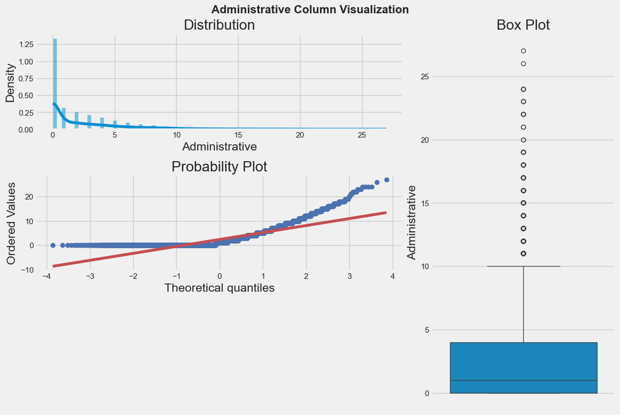

```python
# use plotting_3_chart function to visualize Administrative
plotting_3_chart(df, "Administrative", plot_title="Administrative Column Visualization")
```

**Observations and Insights**

1. **Distribution Plot (Histogram)**
- **Observations**:
  - The data is **right-skewed**, with most values concentrated on the left side (lower values).
  - The peak of the distribution is around **0–5**, indicating that most sessions have a low number of administrative page visits.
  - The density decreases as the number of administrative page visits increases, suggesting that higher values are less frequent.
- **Insight**: The majority of users visit very few administrative pages, with only a small fraction visiting a large number of such pages.
2. **Probability Plot (QQ Plot)**
- **Observations**:
  - The points deviate significantly from the red diagonal line (theoretical quantiles of a normal distribution), especially at the higher values.
  - The deviation at the upper end indicates that the data has a **longer tail** than a normal distribution, confirming the right-skewness observed in the histogram.
- **Insight**: The "Administrative" column does **not follow a normal distribution**. It is skewed, which may require transformations (e.g., log transformation) if normality is required for analysis.
3. **Box Plot**
- **Observations**:
  - The box is concentrated at the lower end of the scale, with the median close to the first quartile, indicating **right-skewness**.
  - There are many **outliers** (dots beyond the whiskers) on the higher end, representing sessions with an unusually high number of administrative page visits.
  - The interquartile range (IQR) is relatively small, suggesting that most of the data lies within a narrow range of low values.
- **Insight**: The presence of outliers suggests that some users exhibit significantly different behavior, possibly exploring administrative pages more extensively than the majority.

### **Observation 2 - Administrative_Duration**

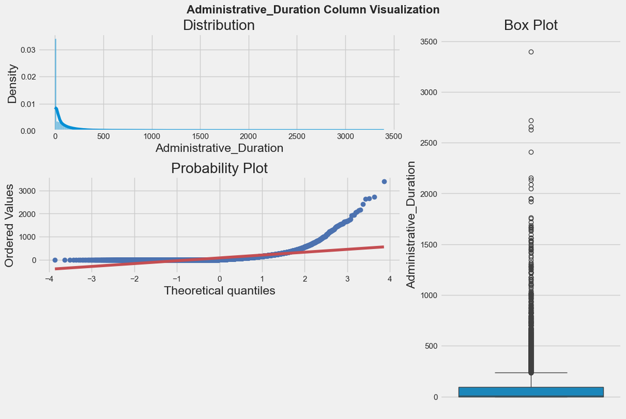

```python
# use plotting_3_chart function to visualize Administrative_Duration
plotting_3_chart(df, "Administrative_Duration", plot_title="Administrative_Duration Column Visualization")
```

**Observations and Insights**

1. **Distribution Plot (Histogram)**
- **Observations**:
  - The data is **right-skewed**, with most values concentrated on the left side (lower values).
  - The peak of the distribution is around **0–500**, indicating that most sessions have a short duration spent on administrative pages.
  - The density decreases as the duration increases, suggesting that longer durations are less frequent.
- **Insight**: The majority of users spend very little time on administrative pages, with only a small fraction spending significantly more time.
2. **Probability Plot (QQ Plot)**
- **Observations**:
  - The points deviate significantly from the red diagonal line (theoretical quantiles of a normal distribution), especially at the higher values.
  - The deviation at the upper end indicates that the data has a **longer tail** than a normal distribution, confirming the right-skewness observed in the histogram.
- **Insight**: The "Administrative_Duration" column does **not follow a normal distribution**. It is skewed, which may require transformations (e.g., log transformation) if normality is required for analysis.
3. **Box Plot**
- **Observations**:
  - The box is concentrated at the lower end of the scale, with the median close to the first quartile, indicating **right-skewness**.
  - There are many **outliers** (dots beyond the whiskers) on the higher end, representing sessions with an unusually long duration spent on administrative pages.
  - The interquartile range (IQR) is relatively small, suggesting that most of the data lies within a narrow range of low durations.
- **Insight**: The presence of outliers suggests that some users exhibit significantly different behavior, possibly spending much more time on administrative pages than the majority.

### **Observation 3 - Informational**

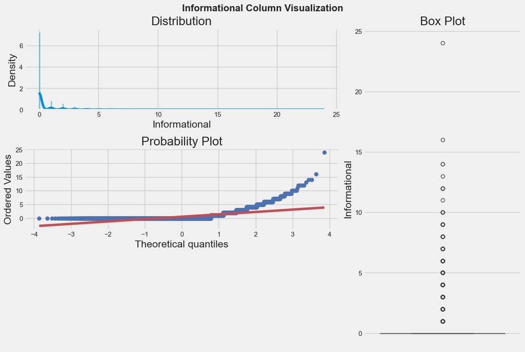

```python
# use plotting_3_chart function to visualize Informational
plotting_3_chart(df, "Informational", plot_title="Informational Column Visualization")
```

**Observations and Insights**

1. **Distribution Plot (Histogram)**
- **Observations**:
  - The data is **right-skewed**, with most values concentrated on the left side (lower values).
  - The peak of the distribution is around **0–5**, indicating that most sessions have a low number of informational page visits.
  - The density decreases as the number of informational page visits increases, suggesting that higher values are less frequent.
- **Insight**: The majority of users visit very few informational pages, with only a small fraction visiting a large number of such pages.
2. **Probability Plot (QQ Plot)**
- **Observations**:
  - The points deviate significantly from the red diagonal line (theoretical quantiles of a normal distribution), especially at the higher values.
  - The deviation at the upper end indicates that the data has a **longer tail** than a normal distribution, confirming the right-skewness observed in the histogram.
- **Insight**: The "Informational" column does **not follow a normal distribution**. It is skewed, which may require transformations (e.g., log transformation) if normality is required for analysis.
3. **Box Plot**
- **Observations**:
  - The box is concentrated at the lower end of the scale, with the median close to the first quartile, indicating **right-skewness**.
  - There are many **outliers** (dots beyond the whiskers) on the higher end, representing sessions with an unusually high number of informational page visits.
  - The interquartile range (IQR) is relatively small, suggesting that most of the data lies within a narrow range of low values.
- **Insight**: The presence of outliers suggests that some users exhibit significantly different behavior, possibly exploring informational pages more extensively than the majority.

### **Observation 4 - Informational_Duration**

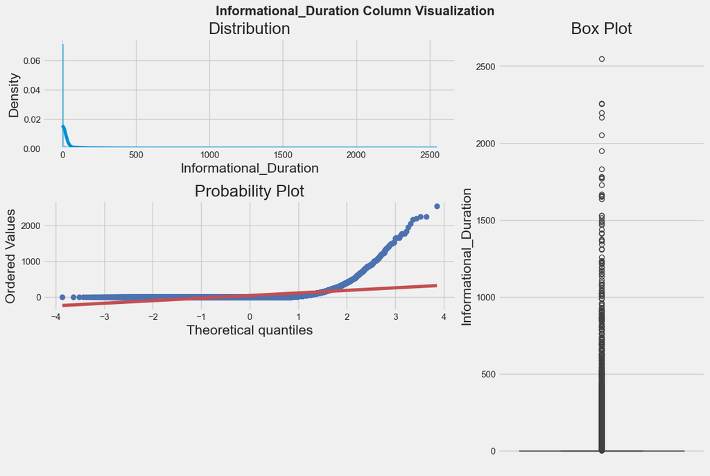

```python
# use plotting_3_chart function to visualize Informational_Duration
plotting_3_chart(df, "Informational_Duration", plot_title="Informational_Duration Column Visualization")
```

**Observations and Insights**

1. **Distribution Plot (Histogram)**
- **Observations**:
  - The data is **right-skewed**, with most values concentrated on the left side (lower values).
  - The peak of the distribution is around **0–500**, indicating that most sessions have a short duration spent on informational pages.
  - The density decreases as the duration increases, suggesting that longer durations are less frequent.
- **Insight**: The majority of users spend very little time on informational pages, with only a small fraction spending significantly more time.
2. **Probability Plot (QQ Plot)**
- **Observations**:
  - The points deviate significantly from the red diagonal line (theoretical quantiles of a normal distribution), especially at the higher values.
  - The deviation at the upper end indicates that the data has a **longer tail** than a normal distribution, confirming the right-skewness observed in the histogram.
- **Insight**: The "Informational_Duration" column does **not follow a normal distribution**. It is skewed, which may require transformations (e.g., log transformation) if normality is required for analysis.
3. **Box Plot**
- **Observations**:
  - The box is concentrated at the lower end of the scale, with the median close to the first quartile, indicating **right-skewness**.
  - There are many **outliers** (dots beyond the whiskers) on the higher end, representing sessions with an unusually long duration spent on informational pages.
  - The interquartile range (IQR) is relatively small, suggesting that most of the data lies within a narrow range of low durations.
- **Insight**: The presence of outliers suggests that some users exhibit significantly different behavior, possibly spending much more time on informational pages than the majority.

### **Observation 5 - ProductRelated**

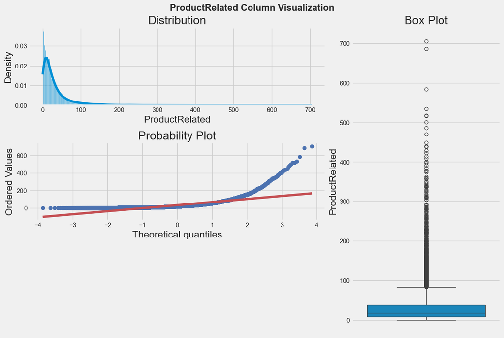

```python
# use plotting_3_chart function to visualize ProductRelated
plotting_3_chart(df, "ProductRelated", plot_title="ProductRelated Column Visualization")
```

**Observations and Insights**

1. **Distribution Plot (Histogram)**
- **Observations**:
  - The data is **right-skewed**, with most values concentrated on the left side (lower values).
  - The peak of the distribution is around **0–100**, indicating that most sessions have a low number of product-related page visits.
  - The density decreases as the number of product-related page visits increases, suggesting that higher values are less frequent.
- **Insight**: The majority of users visit very few product-related pages, with only a small fraction visiting a large number of such pages.
2. **Probability Plot (QQ Plot)**
- **Observations**:
  - The points deviate significantly from the red diagonal line (theoretical quantiles of a normal distribution), especially at the higher values.
  - The deviation at the upper end indicates that the data has a **longer tail** than a normal distribution, confirming the right-skewness observed in the histogram.
- **Insight**: The "ProductRelated" column does **not follow a normal distribution**. It is skewed, which may require transformations (e.g., log transformation) if normality is required for analysis.
3. **Box Plot**
- **Observations**:
  - The box is concentrated at the lower end of the scale, with the median close to the first quartile, indicating **right-skewness**.
  - There are many **outliers** (dots beyond the whiskers) on the higher end, representing sessions with an unusually high number of product-related page visits.
  - The interquartile range (IQR) is relatively small, suggesting that most of the data lies within a narrow range of low values.
- **Insight**: The presence of outliers suggests that some users exhibit significantly different behavior, possibly exploring product-related pages more extensively than the majority.

### **Observation 6 - ProductRelated_Duration**

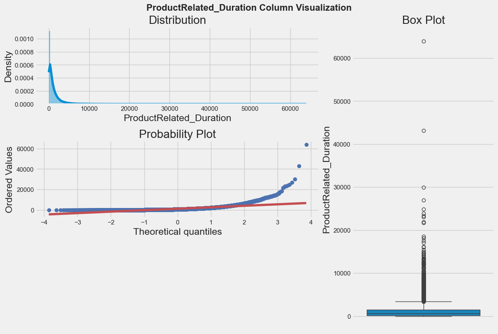

```python
# use plotting_3_chart function to visualize ProductRelated_Duration
plotting_3_chart(df, "ProductRelated_Duration", plot_title="ProductRelated_Duration Column Visualization")
```

**Observations and Insights**

1. **Distribution Plot (Histogram)**
- **Observations**:
  - The data displays a **right-skewed distribution**, with the bulk of values concentrated toward the lower end of the scale.
  - The peak of the distribution is around **0–10000**, indicating that most sessions involve relatively short durations spent on product-related pages.
  - The density diminishes as the duration increases, suggesting that longer durations are less frequent.
- **Insight**: The majority of users spend limited time on product-related pages, with only a small proportion engaging for extended periods. This could imply that most users either quickly find what they need or lose interest early in their browsing session.
2. **Probability Plot (QQ Plot)**
- **Observations**:
  - The points diverge significantly from the red diagonal line (theoretical quantiles of a normal distribution), particularly at the higher durations.
  - The pronounced deviation at the upper end underscores that the data has a **longer tail** than a normal distribution, aligning with the right-skewness observed in the histogram.
- **Insight**: The "ProductRelated_Duration" column does **not adhere to a normal distribution**. Its skewness suggests that transformations (e.g., log or square root) may be necessary if normality is a prerequisite for subsequent analyses.
3. **Box Plot**
- **Observations**:
  - The box is heavily skewed toward the lower end, with the median situated near the first quartile, further emphasizing the **right-skewness** of the data.
  - Numerous **outliers** (dots beyond the whiskers) are evident on the higher end, representing sessions with unusually long durations spent on product-related pages.
  - The interquartile range (IQR) is relatively compact, indicating that the majority of durations fall within a narrow range of low values.
- **Insight**: The presence of outliers highlights that some users exhibit markedly different behavior, potentially spending significantly more time exploring product-related pages. These outliers could represent highly engaged users or instances where users faced difficulties navigating the site, warranting further investigation.

### **Observation 7 - BounceRates**

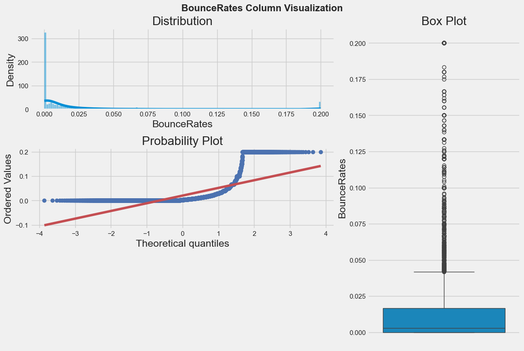

```python
# use plotting_3_chart function to visualize BounceRates
plotting_3_chart(df, "BounceRates", plot_title="BounceRates Column Visualization")
```

**Observations and Insights**

1. **Distribution Plot (Histogram)**
- **Observations**:
  - The data exhibits a **right-skewed distribution**, with the majority of values clustered toward the lower end of the scale.
  - The peak of the distribution is around **0.00–0.05**, suggesting that most sessions have a low bounce rate.
  - The density gradually decreases as the bounce rate increases, indicating that higher bounce rates are less common.
- **Insight**: The majority of users experience low bounce rates, implying that most visitors engage with the site beyond the initial page. However, a smaller subset of sessions shows higher bounce rates, which may indicate areas for improvement in user engagement.
2. **Probability Plot (QQ Plot)**
- **Observations**:
  - The points deviate notably from the red diagonal line (theoretical quantiles of a normal distribution), particularly at the higher bounce rates.
  - The pronounced deviation at the upper end highlights that the data has a **longer tail** than a normal distribution, reinforcing the right-skewness observed in the histogram.
- **Insight**: The "BounceRates" column does **not conform to a normal distribution**. Its skewness suggests that transformations (e.g., log or square root) might be necessary if normality assumptions are required for further analysis.
3. **Box Plot**
- **Observations**:
  - The box is heavily concentrated toward the lower end, with the median positioned close to the first quartile, further confirming the **right-skewness** of the data.
  - Several **outliers** (dots beyond the whiskers) are present on the higher end, representing sessions with unusually high bounce rates.
  - The interquartile range (IQR) is relatively narrow, indicating that the majority of bounce rates fall within a limited range of low values.
- **Insight**: The outliers suggest that certain sessions experience significantly higher bounce rates, potentially pointing to issues such as poor page relevance, slow loading times, or ineffective user engagement strategies. These outliers warrant further investigation to identify and address underlying causes.

### **Observation 8 - ExitRates**

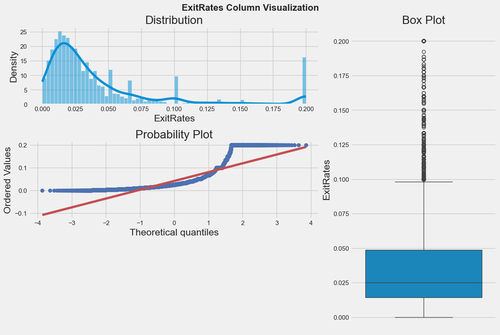

```python
# use plotting_3_chart function to visualize ExitRates
plotting_3_chart(df, "ExitRates", plot_title="ExitRates Column Visualization")
```

**Observations and Insights**

1. **Distribution Plot (Histogram)**
- **Observations**:
  - The data exhibits a **right-skewed distribution**, with the majority of values clustered toward the lower end of the scale.
  - The peak of the distribution is around **0.00–0.05**, suggesting that most sessions have a low exit rate.
  - The density gradually decreases as the exit rate increases, indicating that higher exit rates are less common.
- **Insight**: The majority of users experience low exit rates, implying that most visitors navigate through multiple pages before leaving the site. However, a smaller subset of sessions shows higher exit rates, which may indicate pages where users are more likely to leave the site.
2. **Probability Plot (QQ Plot)**
- **Observations**:
  - The points deviate notably from the red diagonal line (theoretical quantiles of a normal distribution), particularly at the higher exit rates.
  - The pronounced deviation at the upper end highlights that the data has a **longer tail** than a normal distribution, reinforcing the right-skewness observed in the histogram.
- **Insight**: The "ExitRates" column does **not conform to a normal distribution**. Its skewness suggests that transformations (e.g., log or square root) might be necessary if normality assumptions are required for further analysis.
3. **Box Plot**
- **Observations**:
  - The box is heavily concentrated toward the lower end, with the median positioned close to the first quartile, further confirming the **right-skewness** of the data.
  - Several **outliers** (dots beyond the whiskers) are present on the higher end, representing sessions with unusually high exit rates.
  - The interquartile range (IQR) is relatively narrow, indicating that the majority of exit rates fall within a limited range of low values.
- **Insight**: The outliers suggest that certain sessions experience significantly higher exit rates, potentially pointing to issues such as poor page relevance, ineffective navigation, or user dissatisfaction. These outliers warrant further investigation to identify and address underlying causes.

### **Observation 9 - PageValues**

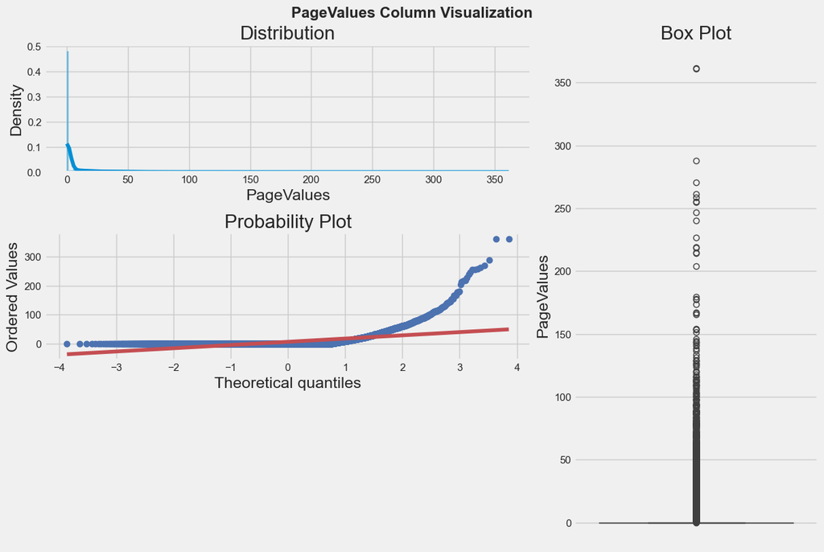

```python
# use plotting_3_chart function to visualize PageValues
plotting_3_chart(df, "PageValues", plot_title="PageValues Column Visualization")
```

**Observations and Insights**

1. **Distribution Plot (Histogram)**
- **Observations**:
  - The data displays a **right-skewed distribution**, with the majority of values concentrated toward the lower end of the scale.
  - The peak of the distribution is around **0–50**, indicating that most pages have a relatively low page value.
  - The density decreases as the page value increases, suggesting that higher page values are less frequent.
- **Insight**: The majority of pages have low values, implying that only a small proportion of pages contribute significantly to driving e-commerce transactions. This highlights the importance of identifying and optimizing high-value pages.
2. **Probability Plot (QQ Plot)**
- **Observations**:
  - The points deviate significantly from the red diagonal line (theoretical quantiles of a normal distribution), particularly at the higher page values.
  - The pronounced deviation at the upper end underscores that the data has a **longer tail** than a normal distribution, aligning with the right-skewness observed in the histogram.
- **Insight**: The "PageValues" column does **not adhere to a normal distribution**. Its skewness suggests that transformations (e.g., log or square root) may be necessary if normality is a prerequisite for subsequent analyses.
3. **Box Plot**
- **Observations**:
  - The box is heavily skewed toward the lower end, with the median situated near the first quartile, further emphasizing the **right-skewness** of the data.
  - Numerous **outliers** (dots beyond the whiskers) are evident on the higher end, representing pages with unusually high values.
  - The interquartile range (IQR) is relatively compact, indicating that the majority of page values fall within a narrow range of low values.
- **Insight**: The presence of outliers highlights that certain pages have significantly higher values, potentially driving a disproportionate share of e-commerce transactions. These high-value pages warrant further analysis to understand their characteristics and replicate their success across other pages.

### **Observation 10 - SpecialDay**

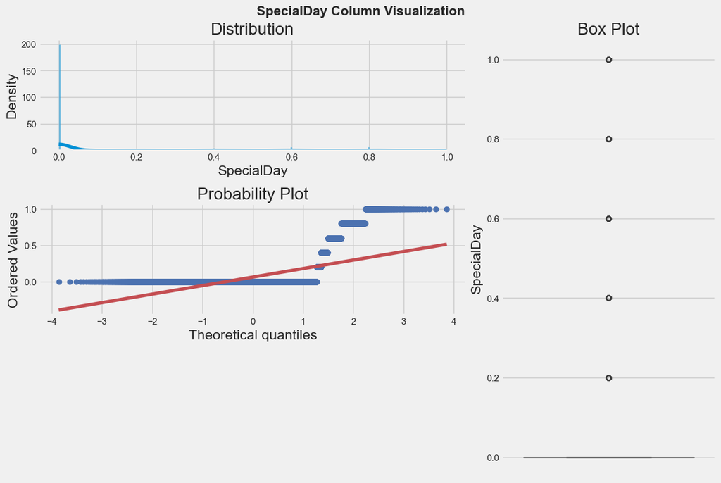

```python
# use plotting_3_chart function to visualize SpecialDay
plotting_3_chart(df, "SpecialDay", plot_title="SpecialDay Column Visualization")
```

**Observations and Insights**

### **Observation 11 - Month**

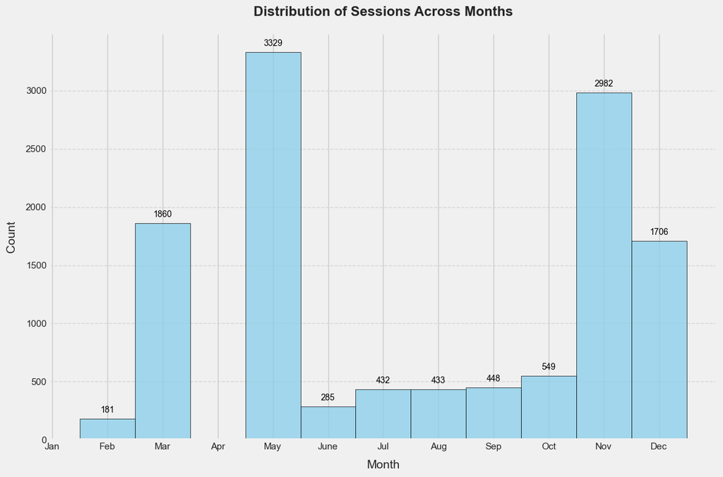

```python
# Visualize the Distribution of Months
customized_displot(df['Month'], title="Distribution of Sessions Across Months")
```

**Observations and Insights**

### **Observation 12 - OperatingSystems**

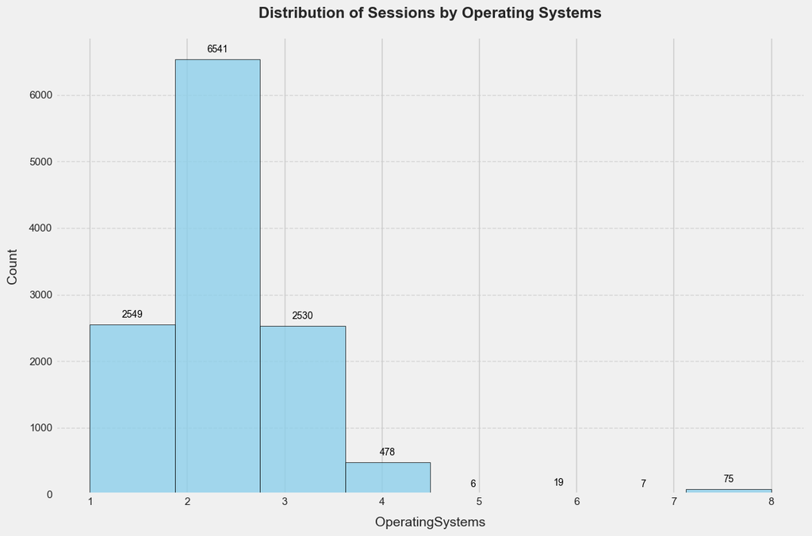

```python
# Visualize the Distribution of Months
customized_displot(df['OperatingSystems'], title="Distribution of Sessions by Operating Systems")
```

**Observations and Insights**

### **Observation 13 - Browser**

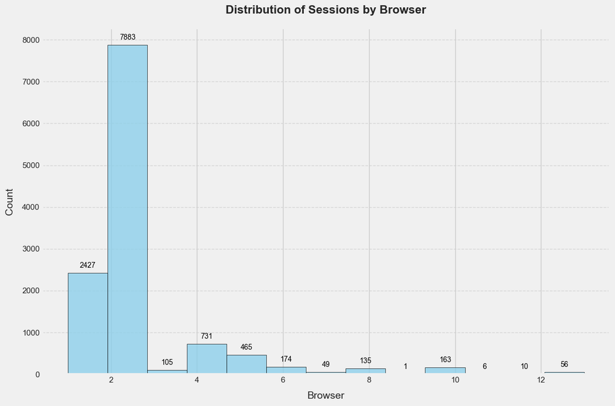

```python
# Visualize the Distribution of Browser
customized_displot(df['Browser'], title="Distribution of Sessions by Browser")
```

**Observations and Insights**

### **Observation 14 - Region**

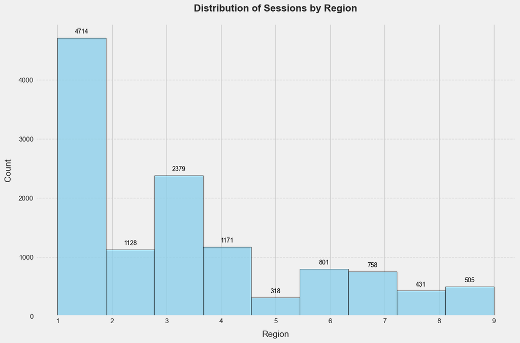

```python
# Visualize the Distribution of Region
customized_displot(df['Region'], title="Distribution of Sessions by Region")
```

**Observations and Insights**

### **Observation 15 - TrafficType**

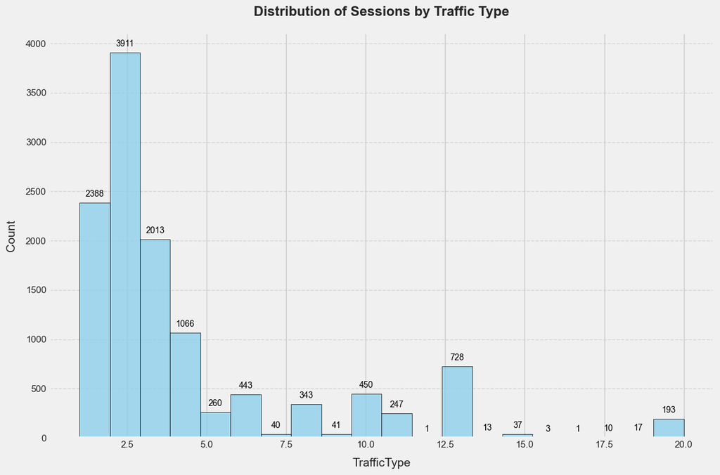

```python
# Visualize the Distribution of TrafficType
customized_displot(df['TrafficType'], title="Distribution of Sessions by Traffic Type")
```

**Observations and Insights**

### **Observation 16 - VisitorType**

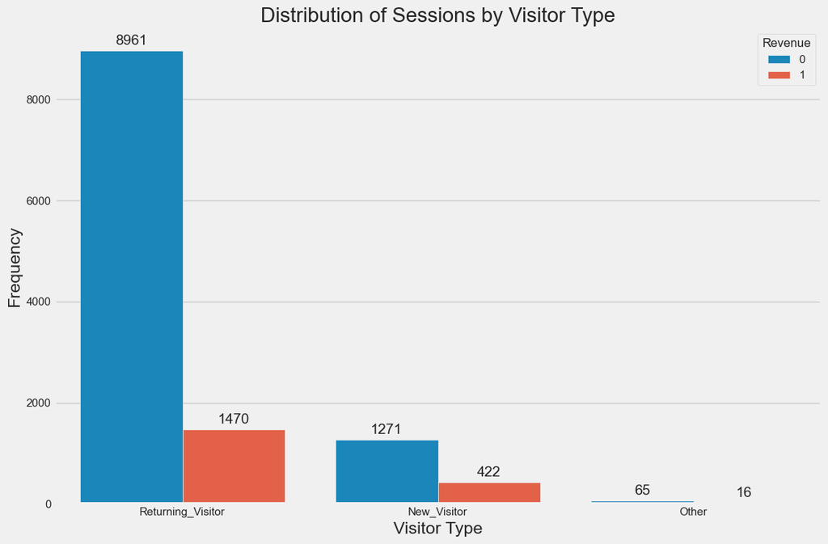

```python
# Visualize the Distribution of VisitorType
plt.figure(figsize=(12, 8))

# Create the countplot
ax = sns.countplot(x=df['VisitorType'],
                  order=df['VisitorType'].value_counts().index,
                  hue=df['Revenue'])

# Add value labels on top of each bar
for container in ax.containers:
    ax.bar_label(container, padding=3)

# Customize the plot
plt.title("Distribution of Sessions by Visitor Type")
plt.xlabel("Visitor Type")
plt.ylabel("Frequency")
plt.legend(title='Revenue')

plt.show()
```

**Observations and Insights**

1. **Distribution of Sessions by Revenue Generation**
- **Observations**:
  - The data shows a **clear distinction between revenue-generating and non-revenue sessions** across visitor types.
  - **Returning Visitors** show:
    - 8,961 non-revenue sessions
    - 1,470 revenue-generating sessions
    - ~14.1% conversion rate
  - **New Visitors** demonstrate:
    - 1,271 non-revenue sessions
    - 422 revenue-generating sessions
    - ~24.9% conversion rate
  - **Other** category shows minimal activity:
    - 65 non-revenue sessions
    - 16 revenue-generating sessions
    - ~19.8% conversion rate
- **Insight**: While Returning Visitors dominate in volume, New Visitors show a higher conversion rate, suggesting they might be more valuable on a per-session basis.
2. **Key Trends**:
- **Traffic Distribution**: Returning Visitors account for approximately 85% of total traffic, indicating strong user retention.
- **Conversion Patterns**: New Visitors show the highest conversion rate (24.9%), followed by Other (19.8%) and Returning Visitors (14.1%).
- **Revenue Generation**: Despite lower volume, New Visitors demonstrate stronger purchasing behavior compared to other segments.

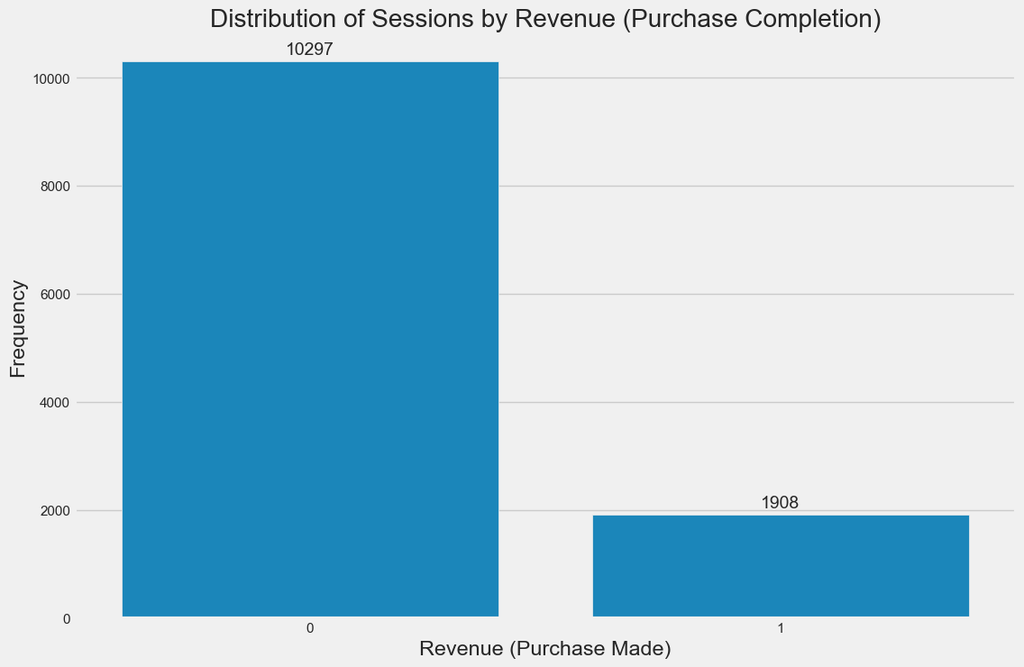

```python
# Visualize the Distribution of Revenue with value labels
plt.figure(figsize=(12, 8))
ax = sns.countplot(x=df['Revenue'], order=df['Revenue'].value_counts().index)

# Add value labels on top of each bar
for i in ax.containers:
    ax.bar_label(i, padding=3)

plt.title("Distribution of Sessions by Revenue (Purchase Completion)")
plt.xlabel("Revenue (Purchase Made)")
plt.ylabel("Frequency")
plt.show()
```

**Observations and Insights**

### **Observation 18 - Revenue**

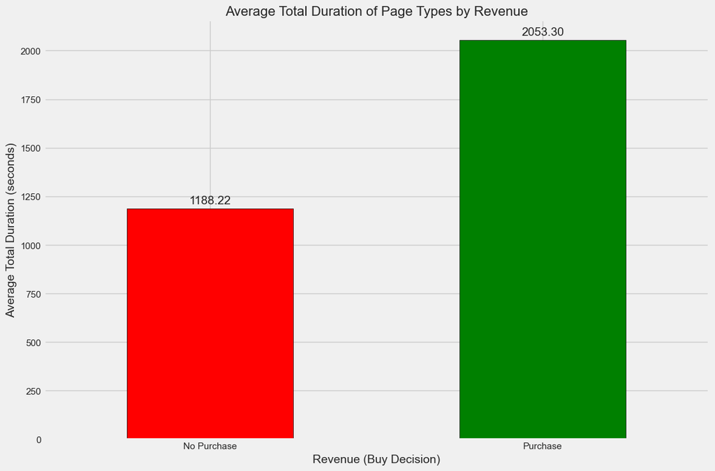

```python
# Make a copy of original dataset
df_copy = df.copy()

# Create a new feature
df_copy['Total_Duration'] = (
    df_copy['Administrative_Duration'] +
    df_copy['Informational_Duration'] +
    df_copy['ProductRelated_Duration']
)

# Grouping by Revenue and calculating the average total duration
duration_revenue_analysis = df_copy.groupby('Revenue')['Total_Duration'].mean()

# Plotting the analysis
plt.figure(figsize=(12, 8))
ax = duration_revenue_analysis.plot(kind='bar', color=['red', 'green'], edgecolor='black')

# Adding value labels on top of each bar
for i in ax.containers:
    ax.bar_label(i, fmt='%.2f', padding=3)  # %.2f formats to 2 decimal places

# Adding labels and title
plt.title('Average Total Duration of Page Types by Revenue', fontsize=16)
plt.xlabel('Revenue (Buy Decision)', fontsize=14)
plt.ylabel('Average Total Duration (seconds)', fontsize=14)
plt.xticks(ticks=[0, 1], labels=['No Purchase', 'Purchase'], rotation=0)
plt.tight_layout()

# Show the plot
plt.show()
```

**Observations and Insights**

1. **Duration Comparison by Purchase Decision**
- **Purchase Sessions (Green)**:
  - Average duration: 2053.30 seconds (~34.2 minutes)
  - Significantly longer duration compared to non-purchase sessions
- **No Purchase Sessions (Red)**:
  - Average duration: 1188.22 seconds (~19.8 minutes)
  - About 42% shorter than purchase sessions
- **Insight**: Sessions resulting in purchases tend to last approximately 14.4 minutes longer than non-purchase sessions.
2. **Key Patterns**:
- **Duration Gap**:
  - Absolute difference: ~865 seconds (14.4 minutes)
  - Relative difference: Purchase sessions are ~73% longer than non-purchase sessions
- **User Behavior Indication**:
  - Longer sessions correlate with higher purchase probability
  - Suggests purchasing customers spend more time researching or comparing products

### **Observation 19 - Correlation Matrix**

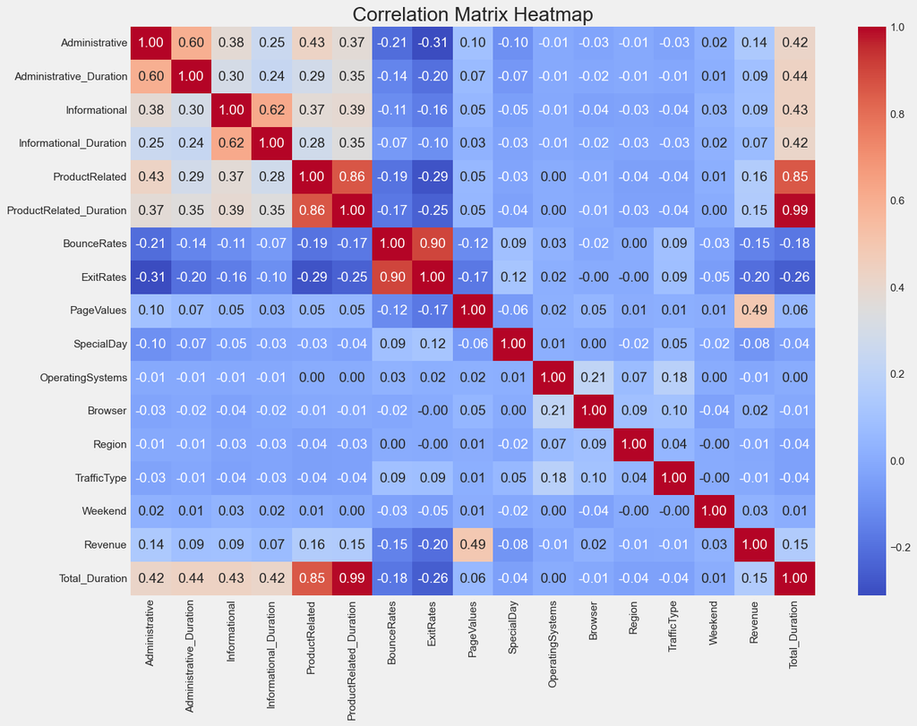

```python
# Compute the correlation matrix
correlation_matrix = df_copy.corr(numeric_only=True)

# Plot the correlation matrix as a heatmap
plt.figure(figsize=(14, 10))
sns.heatmap(correlation_matrix, annot=True, fmt=".2f", cmap='coolwarm', cbar=True)
plt.title("Correlation Matrix Heatmap")
plt.show()
```

**Analysis of Correlation Matrix Heatmap**

1. **Strong Positive Correlations (> 0.7)**
- **Product Related Metrics**:
  - ProductRelated & ProductRelated_Duration (0.86)
  - ProductRelated_Duration & Total_Duration (0.99)
  - ProductRelated & Total_Duration (0.85)
- **Bounce & Exit Rates**:
  - BounceRates & ExitRates (0.90)
2. **Moderate Positive Correlations (0.4 - 0.7)**
- **Administrative Related**:
  - Administrative & Administrative_Duration (0.60)
- **Informational Pages**:
  - Informational & Informational_Duration (0.62)
- **Revenue Indicators**:
  - PageValues & Revenue (0.49)
3. **Notable Negative Correlations**
- **Exit Metrics vs Page Views**:
  - Administrative & ExitRates (-0.31)
  - ProductRelated & ExitRates (-0.29)
  - ProductRelated_Duration & ExitRates (-0.25)
4. **Key Insights for Revenue Prediction**:
- **Strongest Revenue Correlations**:
  - PageValues (0.49)
  - ProductRelated (0.16)
  - ProductRelated_Duration (0.15)
  - Total_Duration (0.15)
  - Administrative (0.14)
- **Negative Revenue Correlations**:
  - ExitRates (-0.20)
  - BounceRates (-0.15)

### **Observation 20 - Average Administrative Duration vs Revenue**

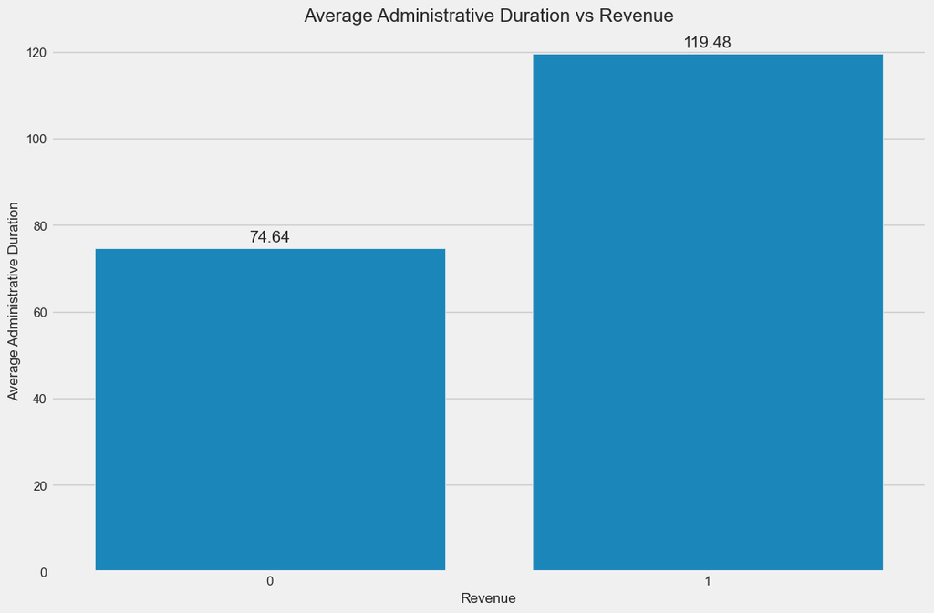

```python
plt.figure(figsize=(12, 8))
ax = sns.barplot(data=df, x='Revenue', y='Administrative_Duration', ci=None)
plt.title('Average Administrative Duration vs Revenue', fontsize=16)
plt.ylabel('Average Administrative Duration', fontsize=12)
plt.xlabel('Revenue', fontsize=12)

# Add text annotations on top of each bar
for i in ax.containers:
    ax.bar_label(i, fmt='%.2f', padding=3)

plt.show()
```

**Analysis of Average Administrative Duration vs Revenue**

### **Observation 21 - Bounce Rate vs Revenue**

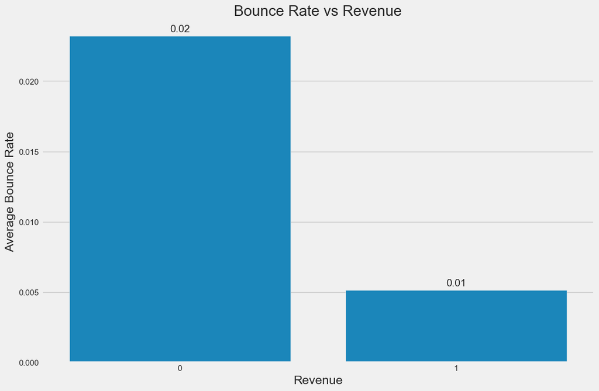

```python
plt.figure(figsize=(12, 8))
ax = sns.barplot(x='Revenue', y='BounceRates', data=df, ci=None, estimator='mean')
plt.title('Bounce Rate vs Revenue')
plt.ylabel('Average Bounce Rate')
plt.xlabel('Revenue')

# Add text annotations on top of each bar
for i in ax.containers:
    ax.bar_label(i, fmt='%.2f', padding=3)

plt.show()
```

**Analysis of Bounce Rate vs Revenue**

### **Observation 22 - Exit Rate vs Revenue**

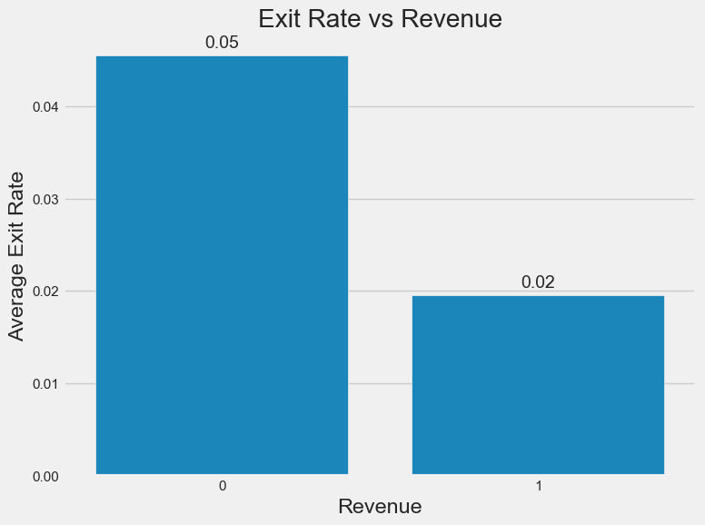

```python
plt.figure(figsize=(8, 6))
ax = sns.barplot(x='Revenue', y='ExitRates', data=df, ci=None, estimator='mean')
plt.title('Exit Rate vs Revenue')
plt.ylabel('Average Exit Rate')
plt.xlabel('Revenue')

# Add text annotations on top of each bar
for i in ax.containers:
    ax.bar_label(i, fmt='%.2f', padding=3)

plt.show()
```

**Analysis of Exit Rate vs Revenue**

1. **Exit Rate Comparison by Revenue Status**
- **Revenue = 0 (Non-Purchase Sessions)**:
  - Average exit rate: ~0.05 (5%)
  - Significantly higher exit rate compared to purchase sessions
- **Revenue = 1 (Purchase Sessions)**:
  - Average exit rate: ~0.02 (2%)
  - Less than half the exit rate of non-purchase sessions
2. **Key Insights**
- **Negative Correlation**:
  - Lower exit rates strongly correlate with purchase behavior
  - Sessions resulting in purchases show better user retention
- **User Behavior Patterns**:
  - Purchasing users tend to stay engaged throughout their session
  - Higher exit rates in non-purchasing sessions suggest:
    - Content may not meet user expectations
    - Navigation issues
    - Pricing or product concerns
    - Lack of compelling calls-to-action

### **Observation 23 - Exit Rate vs Bounce Rate**

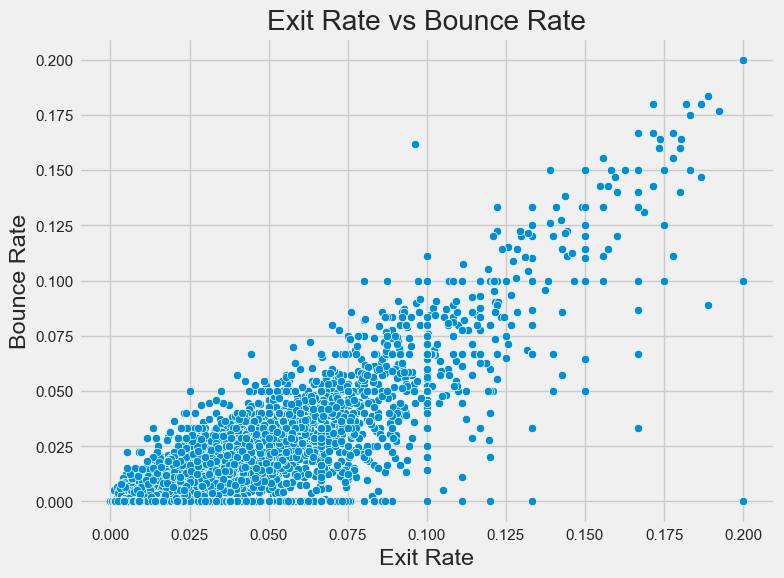

```python
plt.figure(figsize=(8, 6))
sns.scatterplot(x='ExitRates', y='BounceRates', data=df)
plt.title('Exit Rate vs Bounce Rate')
plt.ylabel('Bounce Rate')
plt.xlabel('Exit Rate')
plt.show()
```

**Analysis of Exit Rate vs Bounce Rate Scatter Plot**

1. **Correlation Pattern**
- **Strong Positive Correlation**:
  - Clear upward trend showing bounce rates increase with exit rates
  - Correlation appears to be roughly linear
  - Most dense concentration of points in the lower left quadrant (0.00-0.10 range)
- **Distribution**:
  - Exit Rates: Primarily clustered between 0.00-0.15
  - Bounce Rates: Mainly concentrated between 0.00-0.10
  - Some outliers reaching up to 0.20 for both metrics
2. **Key Observations**
- **Data Density**:
  - Highest density of points in the 0.00-0.075 range for both metrics
  - Scatter becomes more dispersed as rates increase
  - Clear thinning of data points at higher values
- **Pattern Features**:
  - Nearly linear relationship with some variance
  - Wider spread of bounce rates for given exit rates as values increase
  - Few outliers in the upper right corner (high bounce and exit rates)
3. **Statistical Insights**
- **Relationship Strength**:
  - Strong positive correlation (approximately 0.90 based on previous correlation matrix)
  - Predictable relationship useful for forecasting and monitoring
- **Distribution Properties**:
  - Right-skewed distribution for both metrics
  - Non-uniform variance (heteroscedasticity) at higher values
  - Clear boundary effects at 0.00 (natural lower limit)

```python
# Identify outliers with extreme BounceRates and ExitRates where Revenue is True
extreme_bounce_exit = df[(df['Revenue'] == True) &
                           ((df['BounceRates'] > 0.1) | (df['ExitRates'] > 0.1))]

extreme_bounce_exit
```

|  | Administrative | Administrative_Duration | Informational | Informational_Duration | ProductRelated | ProductRelated_Duration | BounceRates | ExitRates | PageValues | SpecialDay | Month | OperatingSystems | Browser | Region | TrafficType | VisitorType | Weekend | Revenue |
| --- | --- | --- | --- | --- | --- | --- | --- | --- | --- | --- | --- | --- | --- | --- | --- | --- | --- | --- |
| 6348 | 1 | 0.0 | 0 | 0.0 | 11 | 113.80 | 0.083333 | 0.116667 | 0.0 | 0.0 | Nov | 2 | 4 | 1 | 3 | Returning_Visitor | 0 | 1 |
| 6615 | 0 | 0.0 | 0 | 0.0 | 1 | 0.00 | 0.200000 | 0.200000 | 0.0 | 0.0 | Oct | 2 | 5 | 1 | 20 | Returning_Visitor | 0 | 1 |
| 7513 | 0 | 0.0 | 0 | 0.0 | 3 | 0.00 | 0.200000 | 0.200000 | 0.0 | 0.0 | Nov | 3 | 2 | 1 | 11 | Returning_Visitor | 0 | 1 |
| 8018 | 2 | 256.5 | 0 | 0.0 | 10 | 117.25 | 0.110714 | 0.130952 | 0.0 | 0.0 | Nov | 2 | 2 | 7 | 11 | Returning_Visitor | 1 | 1 |
| 10430 | 0 | 0.0 | 0 | 0.0 | 8 | 335.25 | 0.100000 | 0.108333 | 0.0 | 0.0 | Nov | 3 | 12 | 1 | 1 | Returning_Visitor | 0 | 1 |
| 10685 | 1 | 0.0 | 0 | 0.0 | 1 | 0.00 | 0.200000 | 0.200000 | 0.0 | 0.0 | Nov | 3 | 2 | 3 | 8 | Returning_Visitor | 0 | 1 |

For those create revenue, have a high bounce rate and exit rate but have 0 duration of the session, consider to drop it. For those with high bounce rate and high exit rate but spend a while in product related page, keep the record.

### **Observation 24 - Page Values vs VisitorType**

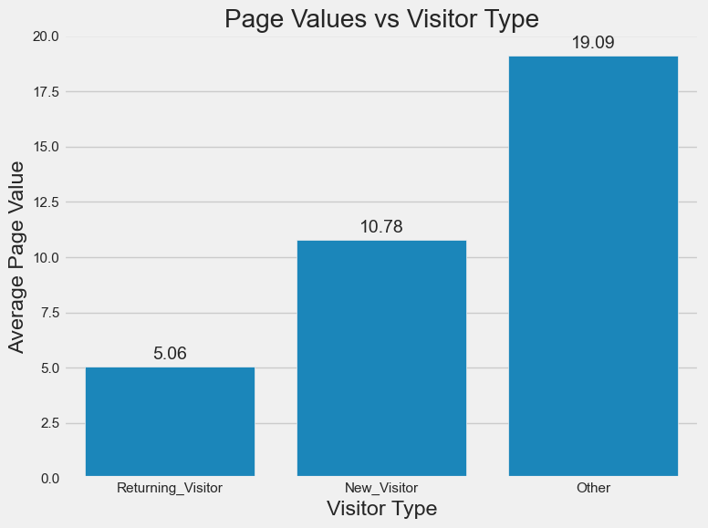

```python
plt.figure(figsize=(8, 6))
ax = sns.barplot(x='VisitorType', y='PageValues', data=df, ci=None, estimator='mean')
plt.title('Page Values vs Visitor Type')
plt.ylabel('Average Page Value')
plt.xlabel('Visitor Type')

# Add text annotations on top of each bar
for i in ax.containers:
    ax.bar_label(i, fmt='%.2f', padding=3)

plt.show()
```

**Analysis of Page Values vs Visitor Type**

1. **Page Value Comparison by Visitor Type**
- **Other Visitors**:
  - Highest average page value: 19.09
  - Significantly higher than both returning and new visitors
- **New Visitors**:
  - Average page value: 10.78
  - Middle-range performance
  - Approximately 2.1x higher than returning visitors
- **Returning Visitors**:
  - Lowest average page value: 5.06
  - Less than half of new visitors' value
  - About 26.5% of "Other" visitors' value
2. **Key Insights**
- **Value Distribution Pattern**:
  - Clear hierarchical pattern in page values
  - Unexpected higher value from "Other" category
  - New visitors generate more value per page than returning visitors
- **Visitor Behavior Indication**:
  - New visitors show higher engagement value
  - Returning visitors might be more browsing-oriented
  - "Other" category shows surprisingly high value (potential anomaly or special case)
- Page Values for Others and New Visitors may be higher because they go straight to the high value page through ads and links whereas Returning Visitors tend to check many pages.

### **Observation 25 - Special Day by Visitor Type**

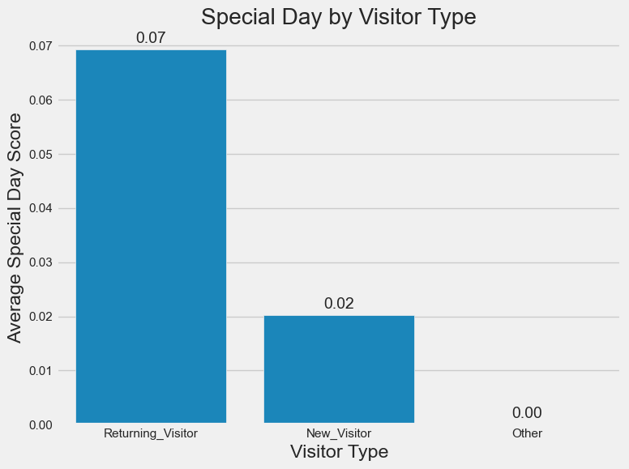

```python
plt.figure(figsize=(8, 6))
ax = sns.barplot(x='VisitorType', y='SpecialDay', data=df, ci=None)
plt.title('Special Day by Visitor Type')
plt.ylabel('Average Special Day Score')
plt.xlabel('Visitor Type')

# Add text annotations on top of each bar
for i in ax.containers:
    ax.bar_label(i, fmt='%.2f', padding=3)

plt.show()
```

**Analysis of Special Day by Visitor Type**

1. **Special Day Score Comparison**
- **Returning Visitors**:
  - Highest average special day score: 0.07 (7%)
  - Significantly higher than other visitor types
  - Shows strongest correlation with special day visits
- **New Visitors**:
  - Moderate special day score: 0.02 (2%)
  - Considerably lower than returning visitors
  - Shows some special day engagement
- **Other Visitors**:
  - Lowest score: 0.00 (0%)
  - No significant special day correlation
  - Suggests minimal holiday/special day influence
2. **Key Insights**
- **Pattern Analysis**:
  - Clear hierarchical distribution
  - Returning visitors show strongest special day engagement
  - Significant drop between returning and new visitors
  - Complete absence of special day correlation for "Other" category
- **Behavioral Indicators**:
  - Returning visitors more likely to engage during special days
  - New visitors show limited special day influence
  - "Other" visitors appear unaffected by special days

### **Observation 26 - Special Day by month**

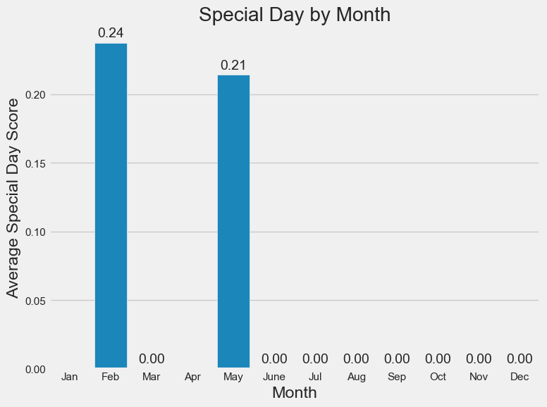

```python
plt.figure(figsize=(8, 6))
ax = sns.barplot(x='Month', y='SpecialDay', data=df, ci=None, estimator='mean')
plt.title('Special Day by Month')
plt.ylabel('Average Special Day Score')
plt.xlabel('Month')

# Add text annotations on top of each bar
for i in ax.containers:
    ax.bar_label(i, fmt='%.2f', padding=3)

plt.show()
```

**Analysis of Special Day Scores by Month**

1. **Monthly Distribution Analysis**
- **Peak Months**:
  - February: Highest score (0.24 or 24%)
  - May: Second highest score (0.21 or 21%)
- **Non-Active Months**:
  - All other months show zero activity (0.00)
  - Including: January, March, April, June-December
- **Pattern**:
  - Only two months show special day activity
  - Clear concentration in first half of year
  - Significant gaps between active months
2. **Key Insights**
- **Seasonal Pattern**:
  - Strong activity in February (likely Valentine's Day)
  - Secondary peak in May (possibly Mother's Day)
  - No activity during major holiday seasons (November-December)
- **Temporal Distribution**:
  - Limited to specific months
  - Focused on commercial holidays
  - Absence of year-end holiday impact

### **Handle Outliers**

```python
# Check for rows where ProductRelated or ProductRelated_Duration is 0 but Revenue is True
zero_product_related_revenue = df_copy[
    ((df_copy['Total_Duration'] == 0)) & (df_copy['Revenue'] == True)
]

zero_product_related_revenue
```

|  | Administrative | Administrative_Duration | Informational | Informational_Duration | ProductRelated | ProductRelated_Duration | BounceRates | ExitRates | PageValues | SpecialDay | Month | OperatingSystems | Browser | Region | TrafficType | VisitorType | Weekend | Revenue | Total_Duration |
| --- | --- | --- | --- | --- | --- | --- | --- | --- | --- | --- | --- | --- | --- | --- | --- | --- | --- | --- | --- |
| 6615 | 0 | 0.0 | 0 | 0.0 | 1 | 0.0 | 0.2 | 0.2 | 0.0 | 0.0 | Oct | 2 | 5 | 1 | 20 | Returning_Visitor | 0 | 1 | 0.0 |
| 7513 | 0 | 0.0 | 0 | 0.0 | 3 | 0.0 | 0.2 | 0.2 | 0.0 | 0.0 | Nov | 3 | 2 | 1 | 11 | Returning_Visitor | 0 | 1 | 0.0 |
| 10685 | 1 | 0.0 | 0 | 0.0 | 1 | 0.0 | 0.2 | 0.2 | 0.0 | 0.0 | Nov | 3 | 2 | 3 | 8 | Returning_Visitor | 0 | 1 | 0.0 |

```python
# Drop rows using the drop method with the specified condition
rows_to_drop = df_copy[(df_copy['Total_Duration'] == 0) & (df_copy['Revenue'] == True)].index
df_copy = df_copy.drop(index=rows_to_drop)
```

```python
# Check the dataset size after deleting
print(f"The dataset has {df_copy.shape[0]} rows and {df_copy.shape[1]} columns")
```

```
The dataset has 12202 rows and 19 columns
```

### **Final Analysis Summary**

**🔑 Key Findings**

#### 1. Visitor Behavior Patterns

- **Returning Visitors (Majority)**
  - Make up 85% of total traffic
  - Lower conversion rate (14.1%)
  - Spend less time per session
  - Lower average page value (5.06)
- **New Visitors**
  - Higher conversion rate (24.9%)
  - Better engagement metrics
  - Higher average page value (10.78)
  - More likely to make purchases
- **Other Visitors**
  - Small segment but highest page value (19.09)
  - Moderate conversion rate (19.8%)
  - Requires further investigation

#### 2. Session Metrics

- **Duration Patterns**
  - Purchase sessions average 34.2 minutes
  - Non-purchase sessions average 19.8 minutes
  - Administrative pages show 60% longer duration for purchasing sessions
- **Engagement Metrics**
  - Strong correlation between bounce rates and exit rates (0.90)
  - Purchase sessions show significantly lower bounce (0.5%) and exit rates (1.9%)
  - Non-purchase sessions have higher bounce (2.2%) and exit rates (4.5%)

#### 3. Temporal Patterns

- **Weekday vs Weekend**
  - 75% of traffic occurs on weekdays
  - Suggests B2B or work-related usage patterns
- **Special Days**
  - Concentrated in February (0.24) and May (0.21)
  - No activity in other months
  - Returning visitors show highest special day engagement (0.07)

**📊 Critical Observations**

#### Strengths

1. Strong user retention (85% returning visitors)
2. High conversion rate for new visitors
3. Clear correlation between engagement metrics and purchases
4. Effective special day campaigns in active months

# **Task 2: Feature Engineering**

In this study, feature engineering was crucial in identifying the most relevant features contributing to model performance. It is primarily used to remove noninformative or redundant features. For supervised learning, to select features, we will locate the target column and split the dataset to ensure that the model does not overfit and that its performance generalizes to new data. Three general feature selection algorithms, filter, wrapper, and embedded methods, are used to evaluate feature choices. For unsupervised learning, we will use the existing framework for feature selection on the clustering task to identify the most relevant features.

## **Feature transformation**

Before applying the feature selection, we need to do ordinal encoding and scaling transformations to our dataset, which prepares it for feature selection. To enhance the feature selection process when modeling, we convert categorical features into numerical values, which makes it possible for embedding methods to assess feature contributions and filter-based and wrapper methods to determine feature importance efficiently. Furthermore, we apply scaling to ensure that features with varied scales are treated similarly and reduce sensitivity to outliers by normalizing numerical data based on the median and interquartile range.

### **Preprocessing**

```python
def preprocess_data_clf(df, categorical_features, numerical_features, target_variable):
    X_train, X_test, y_train, y_test = train_test_split(df.drop(columns=[target_variable]), df[target_variable], test_size=0.2, random_state=42)

    # Initialize encoders and scaler and transformer
    ordinal_encoder = OrdinalEncoder()
    label_encoder = LabelEncoder()
    scaler = RobustScaler()

    # Encode categorical features
    data_train_encoded = pd.DataFrame(ordinal_encoder.fit_transform(X_train[categorical_features]), columns=categorical_features, index=X_train.index)
    data_test_encoded = pd.DataFrame(ordinal_encoder.transform(X_test[categorical_features]), columns=categorical_features, index=X_test.index)

    # Scale numerical features
    data_train_scaled = pd.DataFrame(scaler.fit_transform(X_train[numerical_features]), columns=numerical_features, index=X_train.index)
    data_test_scaled = pd.DataFrame(scaler.transform(X_test[numerical_features]), columns=numerical_features, index=X_test.index)

    # Create copies of the original datasets
    X_train_scaled_encoded = X_train.copy()
    X_test_scaled_encoded = X_test.copy()

    # Update the copies with encoded categorical features and scaled numerical features
    X_train_scaled_encoded[categorical_features] = data_train_encoded
    X_train_scaled_encoded[numerical_features] = data_train_scaled
    X_test_scaled_encoded[categorical_features] = data_test_encoded
    X_test_scaled_encoded[numerical_features] = data_test_scaled

    # Encode the target variable
    y_train_encoded = pd.DataFrame(label_encoder.fit_transform(np.array(y_train).reshape(-1, 1)), columns=[target_variable])
    y_test_encoded = pd.DataFrame(label_encoder.transform(np.array(y_test).reshape(-1, 1)), columns=[target_variable])

    return X_train_scaled_encoded, X_test_scaled_encoded, y_train_encoded, y_test_encoded
```

```python
def preprocess_data_reg(df, categorical_features, numerical_features, target_variable):
    X_train, X_test, y_train, y_test = train_test_split(df.drop(columns=[target_variable]), df[target_variable], test_size=0.2, random_state=42)

    # Initialize encoders and scaler and transformer
    ordinal_encoder = OrdinalEncoder()
    scaler = RobustScaler()
    transformer = QuantileTransformer(output_distribution='normal')

    # Encode categorical features
    data_train_encoded = pd.DataFrame(ordinal_encoder.fit_transform(X_train[categorical_features]), columns=categorical_features, index=X_train.index)
    data_test_encoded = pd.DataFrame(ordinal_encoder.transform(X_test[categorical_features]), columns=categorical_features, index=X_test.index)

    # Scale numerical features
    data_train_scaled = pd.DataFrame(scaler.fit_transform(X_train[numerical_features]), columns=numerical_features, index=X_train.index)
    data_test_scaled = pd.DataFrame(scaler.transform(X_test[numerical_features]), columns=numerical_features, index=X_test.index)

    data_train_scaled = transformer.fit_transform(data_train_scaled)
    data_test_scaled = transformer.transform(data_test_scaled)

    # Create copies of the original datasets
    X_train_scaled_encoded = X_train.copy()
    X_test_scaled_encoded = X_test.copy()

    # Update the copies with encoded categorical features and scaled numerical features
    X_train_scaled_encoded[categorical_features] = data_train_encoded
    X_train_scaled_encoded[numerical_features] = data_train_scaled
    X_test_scaled_encoded[categorical_features] = data_test_encoded
    X_test_scaled_encoded[numerical_features] = data_test_scaled

    return X_train_scaled_encoded, X_test_scaled_encoded, y_train, y_test
```

```python
def preprocess_data_cls(df, categorical_features, numerical_features):
    # Initialize encoders and scaler and transformer
    ordinal_encoder = OrdinalEncoder()
    normalizer = Normalizer()

    # Encode categorical features
    df[categorical_features] = pd.DataFrame(ordinal_encoder.fit_transform(df[categorical_features]), columns=categorical_features, index=df[categorical_features].index)

    # Normalizing numerical features
    df[numerical_features] = pd.DataFrame(normalizer.fit_transform(df[numerical_features]), columns=numerical_features, index=df[numerical_features].index)

    return df
```

### **Splitting dataset**

```python
categorical_features = ['Month', 'VisitorType', 'Weekend']
numerical_features = ['Administrative','Administrative_Duration', 'Informational','Informational_Duration', 'ProductRelated','ProductRelated_Duration', 'BounceRates', 'ExitRates', 'PageValues', 'Total_Duration']
X_train_clf, X_test_clf, y_train_clf, y_test_clf = preprocess_data_clf(df_copy, categorical_features, numerical_features, 'Revenue')
```

```python
categorical_features = ['Month', 'VisitorType', 'Weekend', 'Revenue']
numerical_features = ['Administrative','Administrative_Duration', 'Informational','Informational_Duration', 'ProductRelated', 'BounceRates', 'ExitRates', 'PageValues']
X_train_reg, X_test_reg, y_train_reg, y_test_reg = preprocess_data_reg(df_copy.drop(columns=['Total_Duration']), categorical_features, numerical_features, 'ProductRelated_Duration')
```

```python
categorical_features = ['Month', 'VisitorType', 'Weekend', 'Revenue']
numerical_features = ['Administrative','Administrative_Duration', 'Informational','Informational_Duration', 'ProductRelated','ProductRelated_Duration', 'BounceRates', 'ExitRates', 'PageValues', 'Total_Duration']

df_clustering = preprocess_data_cls(df_copy, categorical_features, numerical_features)
```

## **Feature Selection**

### **Filter-based method**

#### **Variance Threshold**

The threshold method in modeling involves setting a specific cutoff point to classify data into distinct categories or make decisions. This approach is commonly used in binary classification problems, where data points are assigned to one of two groups based on whether they exceed or fall below the threshold.The choice of threshold is critical, as it balances trade-offs between sensitivity and specificity, or between false positives and false negatives. Optimal threshold selection often depends on the context and desired outcomes, and can be determined using techniques like ROC curve analysis or cost-benefit analysis.

##### *Variance Threshold - Classification Task*

```python
def variance_threshold_feature_selection(X, y, thresholds ,problem_type):
    # Store results
    results = []
    selected_features_list = []

    # Test each threshold
    for threshold in thresholds:
        # Apply Variance Threshold
        selector = VarianceThreshold(threshold=threshold)
        X_selected = selector.fit_transform(X)

        # Get the selected features
        selected_features = X.columns[selector.get_support()]
        selected_features_list.append(selected_features)

        # Train a model with selected features
        X_train, X_test, y_train, y_test = train_test_split(X_selected, y, test_size=0.2, random_state=42)

        if problem_type == 'classification':
            model = RandomForestClassifier(random_state=42)
        elif problem_type == 'regression':
            model = RandomForestRegressor(random_state=42)
        else:
            raise ValueError("Invalid problem type. Choose 'classification' or 'regression'.")

        model.fit(X_train, y_train)
        y_pred = model.predict(X_test)

        # Evaluate model
        if problem_type == 'classification':
            metric = accuracy_score(y_test, y_pred)
        else:
            metric = mean_squared_error(y_test, y_pred)

        results.append(metric)

    return results, selected_features_list
```

```python
def plot_vt(thresholds, results, best_threshold):
    plt.figure(figsize=(12, 8))
    plt.plot(thresholds, results, marker='o', linestyle='-', color='b')
    plt.axvline(x=best_threshold, color='r', linestyle='--', label=f'Best Threshold: {best_threshold}')
    plt.xlabel('Variance Threshold')
    plt.ylabel('Model Accuracy')
    plt.title('Model Accuracy vs. Variance Threshold')
    plt.legend()
    plt.grid(True)
    plt.show()
```

```python
thresholds = np.arange(0, .5, 0.01)
```

```python
# Find the best threshold and corresponding features
vt_result_clf, selected_features_clf = variance_threshold_feature_selection(X_train_clf, y_train_clf, thresholds ,"classification")

best_threshold_clf = thresholds[np.argmax(a=vt_result_clf)]
best_features_clf = selected_features_clf[np.argmax(vt_result_clf)]
best_accuracy_clf = np.max(vt_result_clf)

print(f"Best Threshold: {best_threshold_clf}")
print(f"Best Accuracy: {best_accuracy_clf}")
print(f"Selected Features at Best Threshold: {best_features_clf}")
```

```
Best Threshold: 0.04
Best Accuracy: 0.9083461341525858
Selected Features at Best Threshold: Index(['Administrative', 'Administrative_Duration', 'Informational',
       'Informational_Duration', 'ProductRelated', 'ProductRelated_Duration',
       'BounceRates', 'ExitRates', 'PageValues', 'Month', 'OperatingSystems',
       'Browser', 'Region', 'TrafficType', 'VisitorType', 'Weekend',
       'Total_Duration'],
      dtype='object')
```

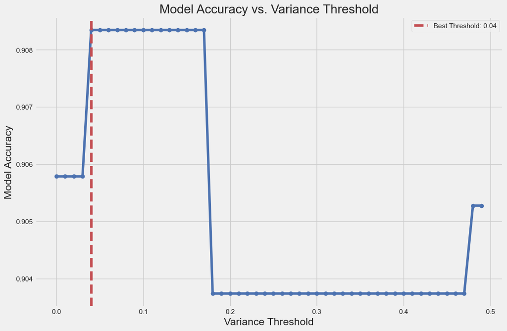

```python
plot_vt(thresholds=thresholds, results=vt_result_clf, best_threshold=best_threshold_clf)
```

The selected threshold is 0.04, yeild the best accuracy of 0.908, and the selected features are:

- **Administrative**
- **Administrative_Duration**
- **Informational**
- **Informational_Duration**
- **ProductRelated**
- **ProductRelated_Duration**
- **BounceRates**
- **ExitRates**
- **PageValues**
- **Month**
- **OperatingSystems**
- **Browser**
- **Region**
- **TrafficType**
- **VisitorType**
- **Weekend**
- **Total_Duration**

##### *Variance Threshold - Regression Task*

```python
# Find the best threshold and corresponding features
vt_result_reg, selected_features_reg = variance_threshold_feature_selection(X_train_reg, y_train_reg, thresholds ,"regression")

best_threshold_reg = thresholds[np.argmax(a=vt_result_reg)]
best_features_reg = selected_features_reg[np.argmax(vt_result_reg)]
best_accuracy_reg = np.max(vt_result_reg)

print(f"Best Threshold: {best_threshold_reg}")
print(f"Best Accuracy (MSE): {best_accuracy_reg}")
print(f"Selected Features at Best Threshold: {best_features_reg}")
```

```
Best Threshold: 0.14
Best Accuracy (MSE): 648575.7689555588
Selected Features at Best Threshold: Index(['Administrative', 'Administrative_Duration', 'Informational',
       'Informational_Duration', 'ProductRelated', 'BounceRates', 'ExitRates',
       'PageValues', 'Month', 'OperatingSystems', 'Browser', 'Region',
       'TrafficType', 'VisitorType', 'Weekend'],
      dtype='object')
```

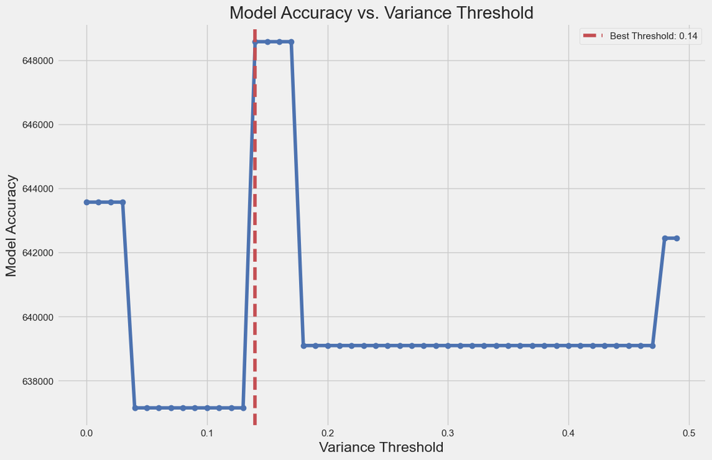

```python
plot_vt(thresholds=thresholds, results=vt_result_reg, best_threshold=best_threshold_reg)
```

#### **Pearson Correlation**

The Pearson correlation used statistical measure that evaluates the strength and direction of the linear relationship between two continuous variables. It produces a coefficient, denoted as r, which ranges from -1 to +1. A value of +1 indicates a perfect positive linear relationship, meaning that as one variable increases, the other variable increases proportionally. Conversely, a value of -1 signifies a perfect negative linear relationship, where one variable increases as the other decreases. A value of 0 suggests no linear relationship between the variables. The Pearson correlation coefficient is calculated by dividing the covariance of the two variables by the product of their standard deviations.

##### *Pearson Correlation - Classification Task*

```python
def pearson_correlation_feature_selection(X, correlation_threshold=0.75):
    # Calculate correlation matrix
    correlation_matrix = X.corr()

    # Find highly correlated pairs
    corr_pairs = []
    for i in range(len(correlation_matrix.columns)):
        for j in range(i):
            if correlation_matrix.iloc[i,j] > correlation_threshold:
                corr_pairs.append((
                    correlation_matrix.columns[i],
                    correlation_matrix.columns[j],
                    correlation_matrix.iloc[i,j]
                ))

    # Identify features to drop based on variance
    features_to_drop = []
    for feat1, feat2, _ in corr_pairs:
        if feat1 != feat2:
            if X[feat1].var() < X[feat2].var():
                features_to_drop.append(feat1)
            else:
                features_to_drop.append(feat2)

    # Remove duplicates from features to drop
    features_to_drop = list(set(features_to_drop))

    # Select features
    selected_features = X.columns[~np.isin(X.columns, features_to_drop)].tolist()

    return selected_features, features_to_drop, corr_pairs
```

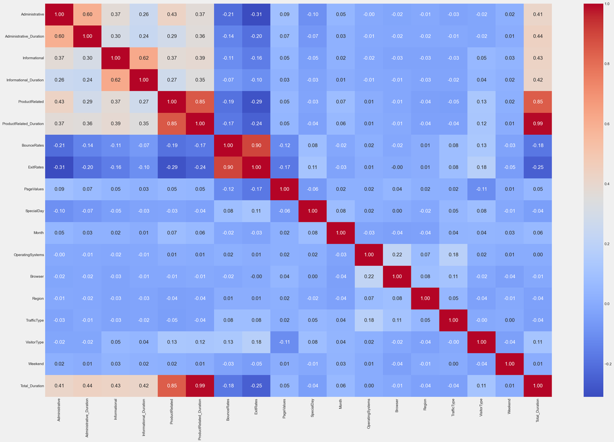

```python
# Get the correlation matrix
correlation_matrix_clf = X_train_clf.corr()

plt.figure(figsize=(30,20))
sns.heatmap(correlation_matrix_clf, annot=True,fmt='.2f',annot_kws=dict(size=15),cmap='coolwarm')
plt.show()
```

```python
selected_features_clf, dropped_features_clf, correlation_pairs_clf = pearson_correlation_feature_selection(X_train_clf, 0.75)
print(f"Correlation pairs: \n {correlation_pairs_clf} \n")
print(f"Dropped features: \n {dropped_features_clf} \n")
print(f"Selected features: \n {selected_features_clf}\n")
```

```
Correlation pairs:
 [('ProductRelated_Duration', 'ProductRelated', np.float64(0.8546482620909359)), ('ExitRates', 'BounceRates', np.float64(0.9018568609351884)), ('Total_Duration', 'ProductRelated', np.float64(0.8463295863235537)), ('Total_Duration', 'ProductRelated_Duration', np.float64(0.9938556366177921))]

Dropped features:
 ['ProductRelated', 'Total_Duration', 'ExitRates']

Selected features:
 ['Administrative', 'Administrative_Duration', 'Informational', 'Informational_Duration', 'ProductRelated_Duration', 'BounceRates', 'PageValues', 'SpecialDay', 'Month', 'OperatingSystems', 'Browser', 'Region', 'TrafficType', 'VisitorType', 'Weekend']
```

```python
rfc = RandomForestClassifier(random_state=42)
rfc.fit(X_train_clf[selected_features_clf], y_train_clf)
y_pred = rfc.predict(X_test_clf[selected_features_clf])

accuracy = accuracy_score(y_test_clf, y_pred)
print(f"Accuracy: {accuracy}")
```

```
Accuracy: 0.9065956575174109
```

And the accuracy is 0.91

##### *Pearson Correlation - Regression Task*

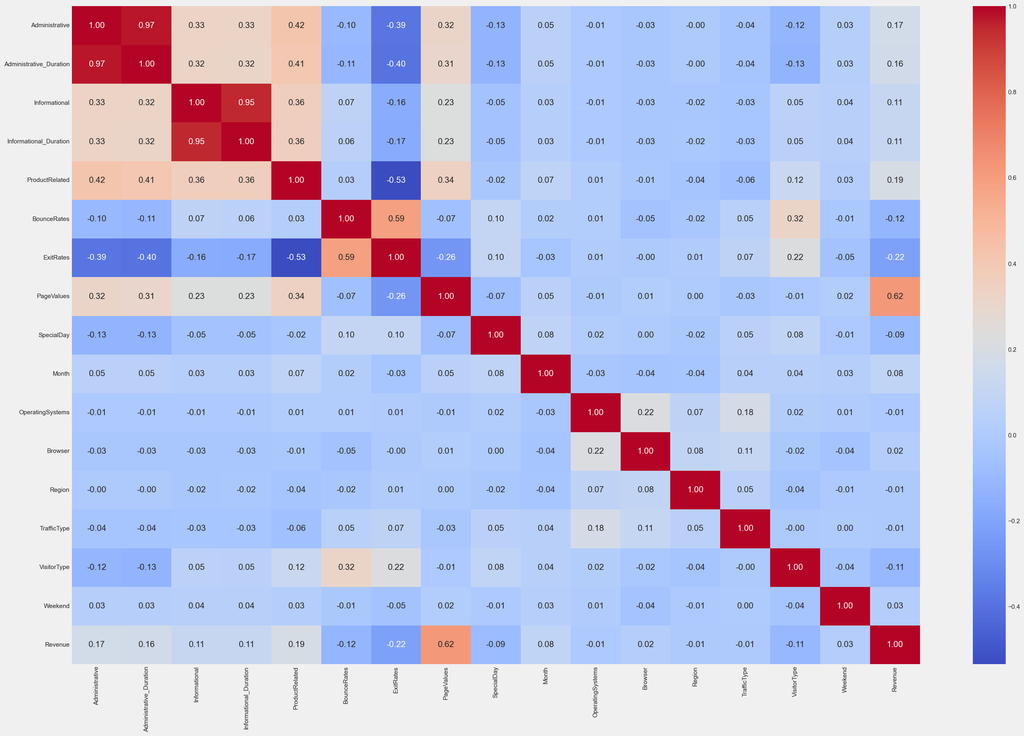

```python
# Get the correlation matrix
correlation_matrix_reg = X_train_reg.corr()

plt.figure(figsize=(30,20))
sns.heatmap(correlation_matrix_reg,annot=True,fmt='.2f',annot_kws=dict(size=15),cmap='coolwarm')
plt.show()
```

```python
selected_features_reg, dropped_features_reg, correlation_pairs_reg = pearson_correlation_feature_selection(X_train_reg, 0.75)
print(f"Correlation pairs: \n {correlation_pairs_reg} \n")
print(f"Dropped features: \n {dropped_features_reg} \n")
print(f"Selected features: \n {selected_features_reg}\n")
```

```
Correlation pairs:
 [('Administrative_Duration', 'Administrative', np.float64(0.9747478563976786)), ('Informational_Duration', 'Informational', np.float64(0.9472916940651559))]

Dropped features:
 ['Informational_Duration', 'Administrative']

Selected features:
 ['Administrative_Duration', 'Informational', 'ProductRelated', 'BounceRates', 'ExitRates', 'PageValues', 'SpecialDay', 'Month', 'OperatingSystems', 'Browser', 'Region', 'TrafficType', 'VisitorType', 'Weekend', 'Revenue']
```

```python
rfg = RandomForestRegressor(random_state=42)
rfg.fit(X_train_reg[selected_features_reg], y_train_reg)
y_pred = rfg.predict(X_test_reg[selected_features_reg])

mse = mean_squared_error(y_test_reg, y_pred)
print(f"Accuracy (MSE): {mse}")
```

```
Accuracy (MSE): 762809.9039098351
```

#### **Mutal Information**

Mutual information (MI) is a measure from information theory that quantifies the amount of information shared between two random variables. It captures both linear and nonlinear relationships, making it more versatile than measures like Pearson correlation, which only assess linear dependencies. Mutual information is based on the concept of entropy, which measures the uncertainty or randomness of a variable. Specifically, MI calculates how much knowing one variable reduces the uncertainty about the other. If two variables are independent, their mutual information is zero, as they provide no information about each other. Conversely, higher mutual information values indicate stronger dependencies. MI is widely used in feature selection, image processing, and machine learning to identify meaningful relationships between variables. However, it can be computationally intensive to estimate, especially for continuous data, and often requires techniques like binning or kernel density estimation for accurate calculation.

##### *Mutual Information - Classification Task*

```python
def mutual_information_feature_selection(X, y, n_features=10, problem_type=None):
    # Calculate mutual information
    mutual_info = 0
    if problem_type == 'classification':
        mutual_info = mutual_info_classif(X, y)
    else:
        mutual_info = mutual_info_regression(X, y)

    # Rank features by mutual information
    mi_scores = pd.Series(mutual_info, index=X.columns).sort_values(ascending=False)

    # Select top N features
    top_features = mi_scores.head(n_features).index.tolist()

    return top_features, mi_scores
```

```python
# Select top 10 features
top_features_mi_clf, mi_scores_clf = mutual_information_feature_selection(X_train_clf, y_train_clf, problem_type="classification")
print("Top 10 Features (Mutual Information):")
print(top_features_mi_clf)
```

```
Top 10 Features (Mutual Information):
['PageValues', 'ExitRates', 'ProductRelated_Duration', 'Total_Duration', 'ProductRelated', 'Administrative', 'BounceRates', 'TrafficType', 'Administrative_Duration', 'Month']
```

```python
rfc = RandomForestClassifier(random_state=42)
rfc.fit(X_train_clf[top_features_mi_clf], y_train_clf)
y_pred = rfc.predict(X_test_clf[top_features_mi_clf])

accuracy = accuracy_score(y_test_clf, y_pred)
print(f"Accuracy: {accuracy}")
```

```
Accuracy: 0.9156083572306432
```

##### *Mutual Information - Regression Task*

```python
# Select top 10 features
top_features_mi_reg, mi_scores_reg = mutual_information_feature_selection(X_train_reg, y_train_reg, problem_type="regression")
print("Top 10 Features (Mutual Information):")
print(top_features_mi_reg)
```

```
Top 10 Features (Mutual Information):
['ProductRelated', 'ExitRates', 'BounceRates', 'Administrative', 'Administrative_Duration', 'PageValues', 'Informational', 'Informational_Duration', 'Revenue', 'TrafficType']
```

```python
rfg = RandomForestRegressor(random_state=42)
rfg.fit(X_train_reg[top_features_mi_reg], y_train_reg)
y_pred = rfg.predict(X_test_reg[top_features_mi_reg])

mse = mean_squared_error(y_test_reg, y_pred)
print(f"MSE: {mse}")
```

```
MSE: 751619.9442252398
```

With the Mutual Information method, the selected features are:

- **ProductRelated**
- **ExitRates**
- **BounceRates**
- **Administrative_Duration**
- **Administrative**
- **PageValues**
- **Informational**
- **Informational_Duration**
- **Revenue**
- **TrafficType**

#### **Conclusion**

**Classification**

The selected features for Filter-based method are:

- **PageValues**
- **ExitRates**
- **ProductRelated_Duration**
- **Total_Duration**
- **BounceRates**
- **ProductRelated**
- **Month**
- **Administrative**
- **Administrative_Duration**
- **TrafficType**

**Regression**

The selected features for Filter-based method are:

### **Embedding-based method**

#### **Lasso L1 Regularization**

Lasso (Least Absolute Shrinkage and Selection Operator) L1 regularization is a powerful technique used in feature selection and regression analysis to improve model interpretability and prevent overfitting. It works by adding a penalty term to the loss function that is proportional to the absolute value of the coefficients (L1 norm). This penalty encourages sparsity, effectively shrinking some coefficients to zero, thereby excluding irrelevant or less important features from the model. As a result, Lasso not only helps in building simpler and more interpretable models but also performs automatic feature selection by retaining only the most significant predictors. This makes it particularly useful in high-dimensional datasets where the number of features exceeds the number of observations.

##### *Lasso L1 Regularization - Classification Task*

```python
def lasso_feature_selection(X, y, alpha=0.01, threshold=1e-5):
    # Initialize and train Lasso model
    lasso = Lasso(alpha=alpha)
    lasso.fit(X, y)

    # Get feature coefficients
    coef_series = pd.Series(lasso.coef_, index=X.columns)

    # Select features with non-zero coefficients
    selected_features = coef_series[abs(coef_series) > threshold].index.tolist()

    df_coeff = pd.DataFrame({"features":X.columns,"coeff":coef_series.values})
    df_coeff.sort_values("coeff", inplace=True)

    return selected_features, coef_series, df_coeff
```

```python
selected_features_l1_clf, coef_series_clf, coef_df_clf = lasso_feature_selection(X_train_clf, y_train_clf)
print(f"Selected features: \n {selected_features_l1_clf}\n")
print(f"Coef serires: \n {coef_df_clf}\n")
```

```
Selected features:
 ['Informational_Duration', 'ProductRelated', 'ProductRelated_Duration', 'ExitRates', 'PageValues', 'Month', 'VisitorType']

Coef serires:
                    features     coeff
7                 ExitRates -0.020828
15              VisitorType -0.008460
2             Informational  0.000000
0            Administrative  0.000000
6               BounceRates -0.000000
12                  Browser  0.000000
9                SpecialDay -0.000000
1   Administrative_Duration  0.000000
13                   Region -0.000000
14              TrafficType -0.000000
11         OperatingSystems -0.000000
16                  Weekend  0.000000
17           Total_Duration  0.000000
3    Informational_Duration  0.000022
10                    Month  0.007463
5   ProductRelated_Duration  0.008359
8                PageValues  0.008874
4            ProductRelated  0.013797
```

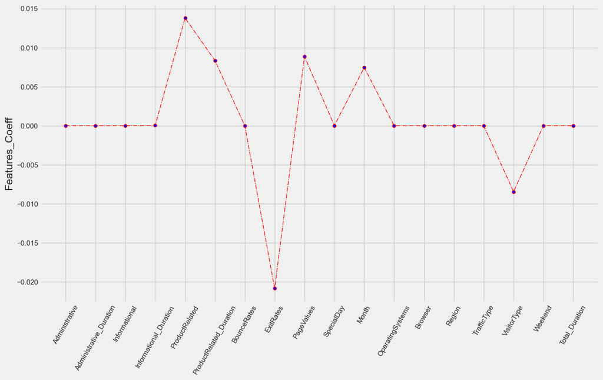

```python
# Lets plot the coeff with features
plt.figure(figsize=(14,8))
plt.plot(range(len(X_train_clf.columns)), coef_series_clf, color='red', linestyle='dashdot', linewidth = 1,marker='o',
         markerfacecolor='blue', markersize=5)
plt.xticks(range(len(X_train_clf.columns)),X_train_clf.columns,rotation=60)
plt.ylabel("Features_Coeff")
plt.show()
```

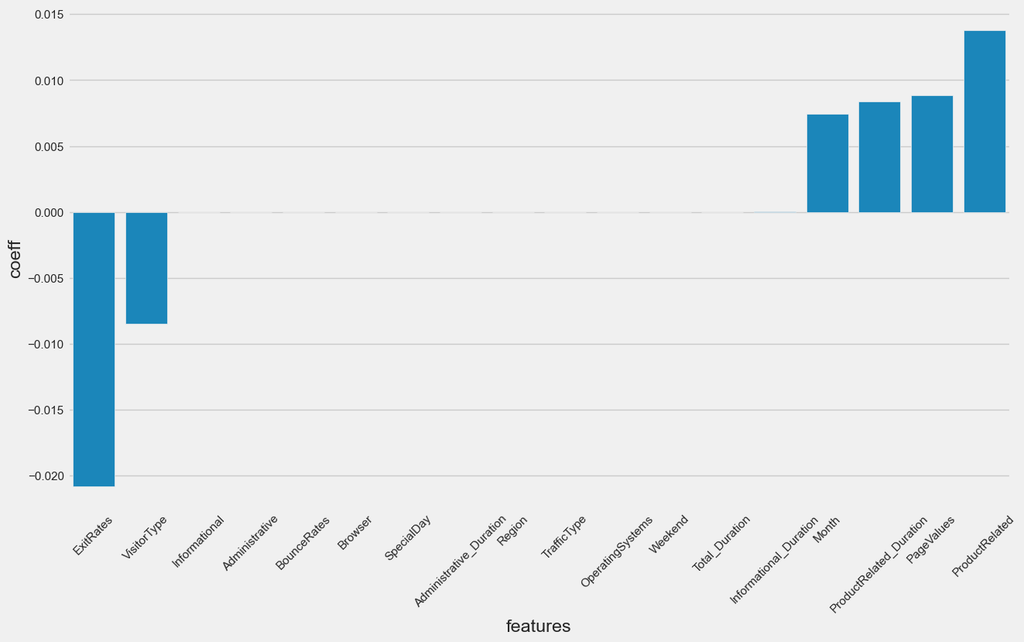

```python
# Use Bar chart to show coeff
plt.figure(figsize=(14,8))
# plot the feature coeff in bars.
plt.xticks(rotation=45)
sns.barplot(x="features",y= "coeff", data=coef_df_clf)
```

```python
rfc = RandomForestClassifier(random_state=42)
etc = ExtraTreesClassifier(random_state=42)
gbc = GradientBoostingClassifier(random_state=42)
dtc = DecisionTreeClassifier(random_state=42)

rfc.fit(X_train_clf[selected_features_l1_clf], y_train_clf)
etc.fit(X_train_clf[selected_features_l1_clf], y_train_clf)
gbc.fit(X_train_clf[selected_features_l1_clf], y_train_clf)
dtc.fit(X_train_clf[selected_features_l1_clf], y_train_clf)

accuracy_rfc = accuracy_score(y_test_clf, rfc.predict(X_test_clf[selected_features_l1_clf]))
accuracy_etc = accuracy_score(y_test_clf, etc.predict(X_test_clf[selected_features_l1_clf]))
accuracy_gbc = accuracy_score(y_test_clf, gbc.predict(X_test_clf[selected_features_l1_clf]))
accuracy_dtc = accuracy_score(y_test_clf, dtc.predict(X_test_clf[selected_features_l1_clf]))

print(f"Accuracy of Random Forest: {accuracy_rfc}")
print(f"Accuracy of Extra Trees: {accuracy_etc}")
print(f"Accuracy of Gradient Boosting: {accuracy_gbc}")
print(f"Accuracy of Decision Tree: {accuracy_dtc}")
```

```
Accuracy of Random Forest: 0.8984022941417452
Accuracy of Extra Trees: 0.8971732896353953
Accuracy of Gradient Boosting: 0.911102007374027
Accuracy of Decision Tree: 0.8627611634575993
```

Selected features from Lasso L1 Regularization are:

- **Informational_Duration**
- **ProductRelated**
- **ProductRelated_Duration**
- **ExitRates**
- **PageValues**
- **Month**
- **VisitorType**